# Time dependent Cox: sensitivity analysis in patients aged 65 and above

```r
ggcoxzph(resm5)[2]
```

```
## $`2`
```

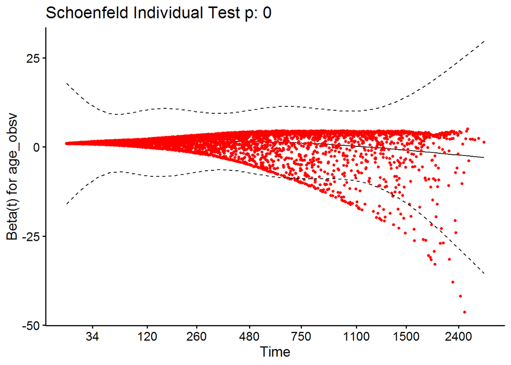

```r
ggcoxzph(resm5)[3]
```

```
## $`3`
```

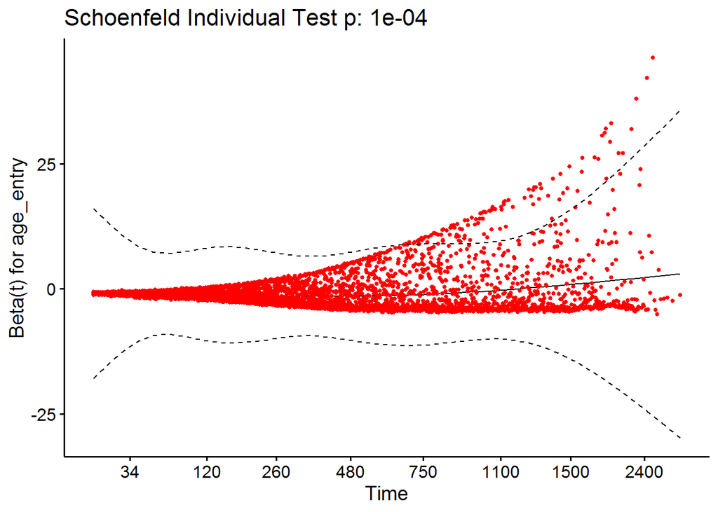

```r
anova(cox_m5)
```

```
## Analysis of Deviance Table
##  Cox model: response is Surv(time1, time2, event_death)
## Terms added sequentially (first to last)
##
##              loglik     Chisq Df Pr(>|Chi|)
## NULL         -41451
## Gender_Value -41449    2.9406  1    0.08638 .
## age_obsv     -40698 1503.4388  1    < 2e-16 ***
## age_entry    -40270  855.0895  1    < 2e-16 ***
## ---
## Signif. codes:  0 '***' 0.001 '**' 0.01 '*' 0.05 '.' 0.1 ' ' 1
```

**Gender, age at observation, and age of diagnosis**

```r
cox_m6 <- coxph(Surv(time1, time2, event_death) ~ Gender_Value + age_obsv + age_diag, data = all_df)

summary(cox_m6)
```

```
## Call:
## coxph(formula = Surv(time1, time2, event_death) ~ Gender_Value +
##     age_obsv + age_diag, data = all_df)
##
##   n= 56624, number of events= 5065
##
##                      coef exp(coef) se(coef)       z Pr(>|z|)
## Gender_ValueMale  0.17942   1.19652  0.02907   6.172 6.74e-10 ***
## age_obsv          0.37809   1.45949  0.01348  28.040  < 2e-16 ***
## age_diag         -0.29404   0.74525  0.01325 -22.190  < 2e-16 ***
## ---
## Signif. codes:  0 '***' 0.001 '**' 0.01 '*' 0.05 '.' 0.1 ' ' 1
##
##                  exp(coef) exp(-coef) lower .95 upper .95
## Gender_ValueMale    1.1965     0.8358    1.1303    1.2667
## age_obsv            1.4595     0.6852    1.4214    1.4986
## age_diag            0.7452     1.3418    0.7261    0.7649
##
## Concordance= 0.671  (se = 0.004 )
## Likelihood ratio test= 2002  on 3 df,   p=<2e-16
## Wald test            = 1841  on 3 df,   p=<2e-16
## Score (logrank) test = 1816  on 3 df,   p=<2e-16
```

```r
cox.zph(cox_m6)
```

```
##              chisq df      p
## Gender_Value 0.982  1 0.3216
## age_obsv     6.100  1 0.0135
## age_diag     6.729  1 0.0095
## GLOBAL       9.065  3 0.0284
```

```r
resm6 <- cox.zph(cox_m6)

ggcoxzph(resm6)[1]
```

```
## $`1`
```

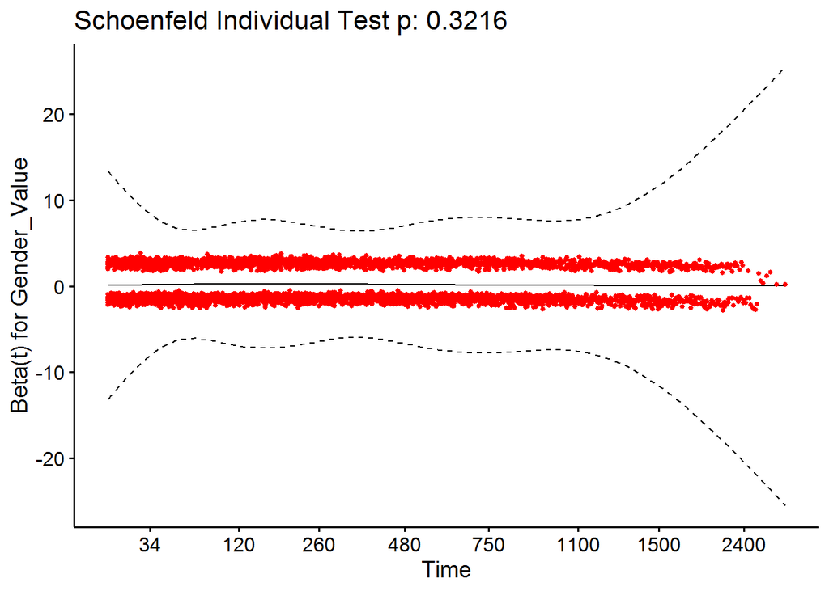

```r
ggcoxzph(resm6)[2]
```

```
## $`2`
```

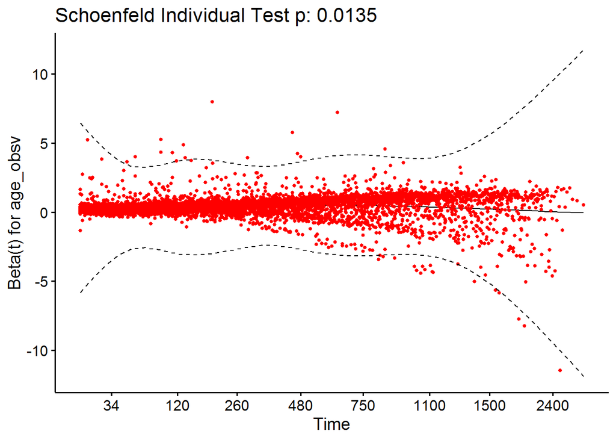

```r
ggcoxzph(resm6)[3]
```

```
## $`3`
```

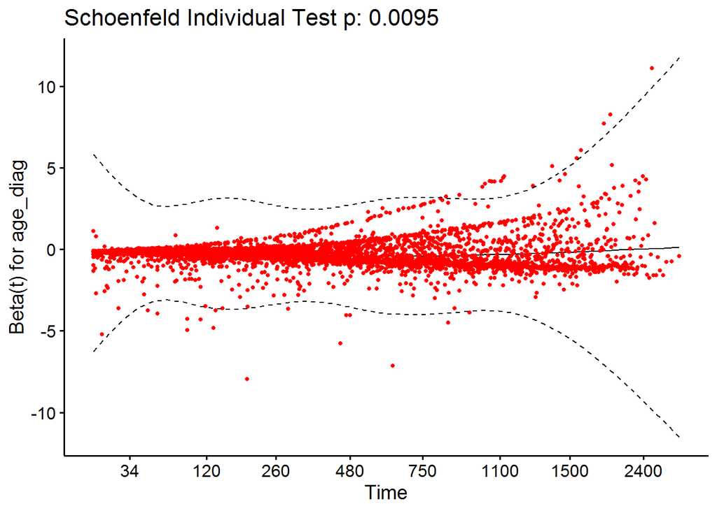

```r
anova(cox_m6)
```

```
## Analysis of Deviance Table
##  Cox model: response is Surv(time1, time2, event_death)
## Terms added sequentially (first to last)
##
##              loglik     Chisq Df Pr(>|Chi|)
## NULL         -41451
## Gender_Value -41449    2.9406  1    0.08638 .
## age_obsv     -40698 1503.4388  1    < 2e-16 ***
## age_diag     -40450  495.3895  1    < 2e-16 ***
## ---
## Signif. codes:  0 '***' 0.001 '**' 0.01 '*' 0.05 '.' 0.1 ' ' 1
```

**Gender, age at observation, and dementia medication exposure**

```r
cox_m7 <- coxph(Surv(time1, time2, event_death) ~ Gender_Value + age_obsv + med_exposure, data = all_df)

summary(cox_m7)
```

```
## Call:
## coxph(formula = Surv(time1, time2, event_death) ~ Gender_Value +
##     age_obsv + med_exposure, data = all_df)
##
##   n= 56624, number of events= 5065
##
##                           coef exp(coef) se(coef)      z Pr(>|z|)
## Gender_ValueMale      0.216151  1.241289 0.029018  7.449 9.42e-14 ***
## age_obsv              0.086196  1.090020 0.002255 38.231  < 2e-16 ***
## med_exposureunexposed 0.232177  1.261342 0.029562  7.854 4.03e-15 ***
## ---
## Signif. codes:  0 '***' 0.001 '**' 0.01 '*' 0.05 '.' 0.1 ' ' 1
##
##                       exp(coef) exp(-coef) lower .95 upper .95
## Gender_ValueMale          1.241     0.8056     1.173     1.314
## age_obsv                  1.090     0.9174     1.085     1.095
## med_exposureunexposed     1.261     0.7928     1.190     1.337
##
## Concordance= 0.664  (se = 0.005 )
## Likelihood ratio test= 1567  on 3 df,   p=<2e-16
## Wald test            = 1485  on 3 df,   p=<2e-16
## Score (logrank) test = 1513  on 3 df,   p=<2e-16
```

```r
cox.zph(cox_m7)
```

```
##                 chisq df      p
## Gender_Value   0.0769  1   0.78
## age_obsv       1.4297  1   0.23
## med_exposure 134.8776  1 <2e-16
## GLOBAL       140.7721  3 <2e-16
```

```r
resm7 <- cox.zph(cox_m7)

ggcoxzph(resm7)[1]
```

```
## $`1`
```

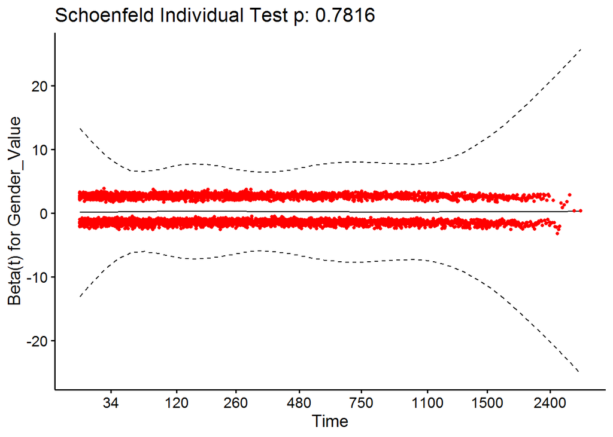

```r
ggcoxzph(resm7)[2]
```

```
## $`2`
```

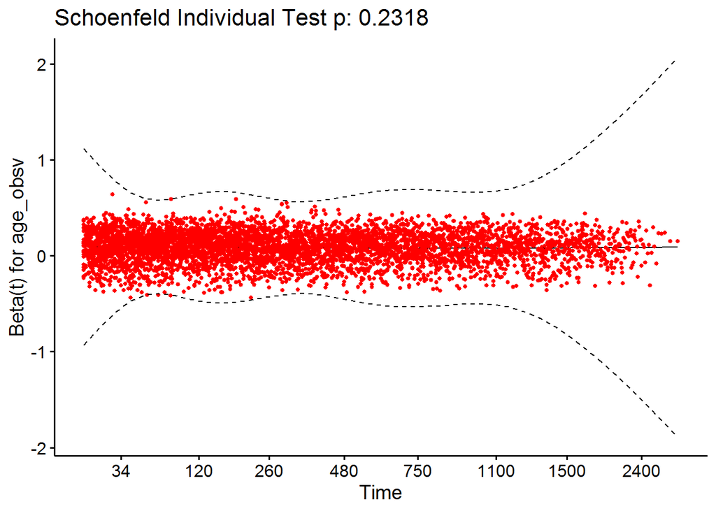

```r
ggcoxzph(resm7)[3]
```

```
## $`3`
```

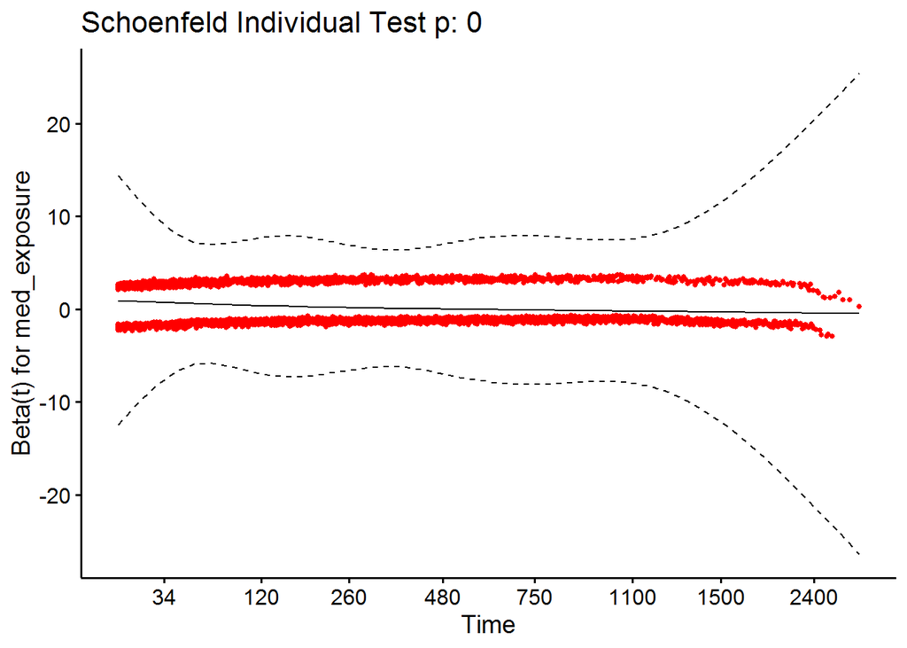

```r
anova(cox_m7)
```

```
## Analysis of Deviance Table
##  Cox model: response is Surv(time1, time2, event_death)
## Terms added sequentially (first to last)
##
##              loglik     Chisq Df Pr(>|Chi|)
## NULL         -41451
## Gender_Value -41449    2.9406  1    0.08638 .
## age_obsv     -40698 1503.4388  1  < 2.2e-16 ***
## med_exposure -40668   60.3039  1  8.129e-15 ***
## ---
## Signif. codes:  0 '***' 0.001 '**' 0.01 '*' 0.05 '.' 0.1 ' ' 1
```

**Gender, age at observation, and initial diagnosis**

```r
cox_m8 <- coxph(Surv(time1, time2, event_death) ~ Gender_Value + age_obsv + cause_diagper,
                data = all_df)

summary(cox_m8)
```

```
## Call:
## coxph(formula = Surv(time1, time2, event_death) ~ Gender_Value +
##     age_obsv + cause_diagper, data = all_df)
##
##   n= 56624, number of events= 5065
##
##                              coef exp(coef) se(coef)      z Pr(>|z|)
## Gender_ValueMale         0.208815  1.232217 0.029044  7.190 6.50e-13 ***
## age_obsv                 0.084801  1.088500 0.002262 37.484  < 2e-16 ***
## cause_diagperDLB         0.259572  1.296375 0.095895  2.707  0.00679 **
## cause_diagperFTD         0.112811  1.119420 0.225250  0.501  0.61649
## cause_diagperMixedADVaD  0.101077  1.106361 0.138472  0.730  0.46543
## cause_diagperPPD         0.657504  1.929968 0.289921  2.268  0.02334 *
## cause_diagperUnspecified 0.138770  1.148860 0.031226  4.444 8.83e-06 ***
## cause_diagperVaD         0.385452  1.470279 0.061023  6.316 2.68e-10 ***
## ---
## Signif. codes:  0 '***' 0.001 '**' 0.01 '*' 0.05 '.' 0.1 ' ' 1
##
##                          exp(coef) exp(-coef) lower .95 upper .95
## Gender_ValueMale             1.232     0.8115    1.1640     1.304
## age_obsv                     1.088     0.9187    1.0837     1.093
## cause_diagperDLB             1.296     0.7714    1.0742     1.564
## cause_diagperFTD             1.119     0.8933    0.7199     1.741
## cause_diagperMixedADVaD      1.106     0.9039    0.8434     1.451
## cause_diagperPPD             1.930     0.5181    1.0934     3.407
## cause_diagperUnspecified     1.149     0.8704    1.0807     1.221
## cause_diagperVaD             1.470     0.6801    1.3045     1.657
##
## Concordance= 0.66  (se = 0.005 )
## Likelihood ratio test= 1556  on 8 df,   p=<2e-16
## Wald test            = 1459  on 8 df,   p=<2e-16
## Score (logrank) test = 1487  on 8 df,   p=<2e-16
```

```r
cox.zph(cox_m8)
```

```
##                 chisq df       p
## Gender_Value   0.0609  1 0.80514
## age_obsv       2.1874  1 0.13914
## cause_diagper 23.8619  6 0.00055
## GLOBAL        26.2026  8 0.00097
```

```r
resm8 <- cox.zph(cox_m8)

ggcoxzph(resm8)[1]
```

```
## $`1`
```

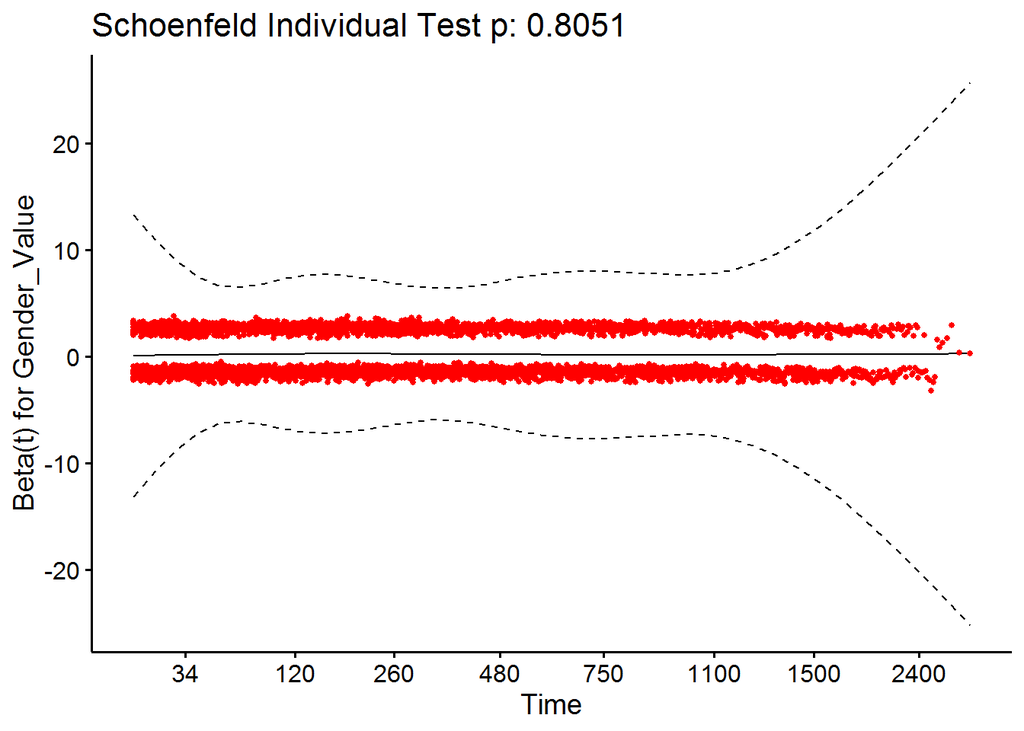

```r
ggcoxzph(resm8)[2]
```

```
## $`2`
```

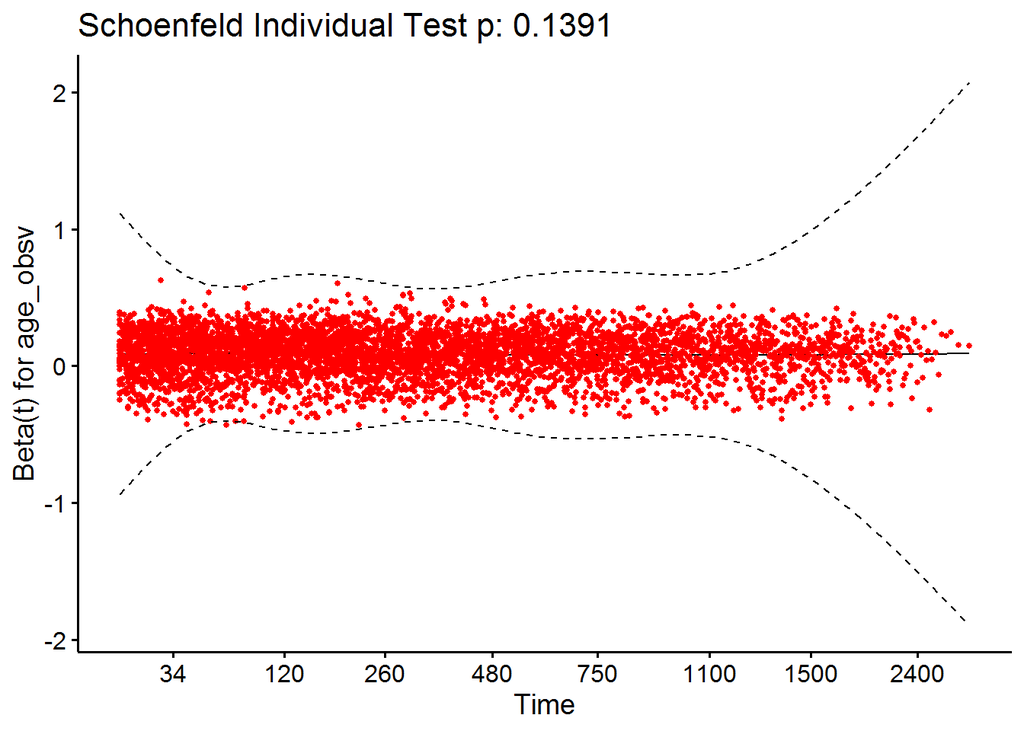

```r
ggcoxzph(resm8)[3]
```

```
## $`3`
```

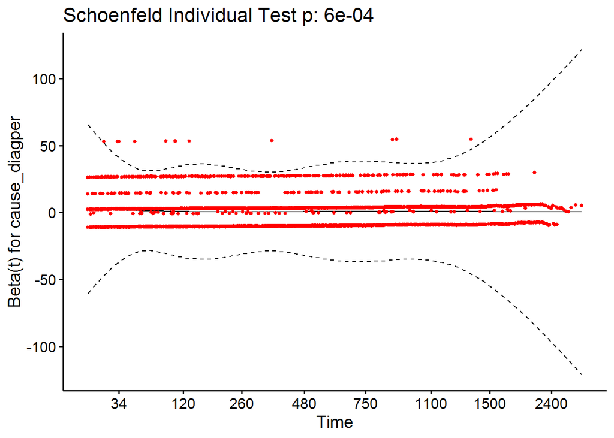

```r
anova(cox_m8)
```

```
## Analysis of Deviance Table
##  Cox model: response is Surv(time1, time2, event_death)
## Terms added sequentially (first to last)
##
##               loglik     Chisq Df Pr(>|Chi|)
## NULL          -41451
## Gender_Value  -41449    2.9406  1    0.08638 .
## age_obsv      -40698 1503.4388  1  < 2.2e-16 ***
## cause_diagper -40673   50.0940  6  4.501e-09 ***
## ---
## Signif. codes:  0 '***' 0.001 '**' 0.01 '*' 0.05 '.' 0.1 ' ' 1
```

**Gender, age at observation, and racial group**

```r
cox_m9 <- coxph(Surv(time1, time2, event_death) ~ Gender_Value + age_obsv + Ethnicity_Value, data = all_df)

summary(cox_m9)
```

```
## Call:
## coxph(formula = Surv(time1, time2, event_death) ~ Gender_Value +
##     age_obsv + Ethnicity_Value, data = all_df)
##
##   n= 40715, number of events= 3557
##    (15909 observations deleted due to missingness)
##
##                           coef exp(coef)  se(coef)      z Pr(>|z|)
## Gender_ValueMale      0.185797  1.204178  0.034866  5.329 9.88e-08 ***
## age_obsv              0.083771  1.087380  0.002711 30.897  < 2e-16 ***
## Ethnicity_ValueOther -0.005492  0.994523  0.175291 -0.031    0.975
## Ethnicity_ValueAsian -0.218334  0.803857  0.209762 -1.041    0.298
## Ethnicity_ValueBlack  0.253070  1.287974  0.224416  1.128    0.259
## ---
## Signif. codes:  0 '***' 0.001 '**' 0.01 '*' 0.05 '.' 0.1 ' ' 1
##
##                      exp(coef) exp(-coef) lower .95 upper .95
## Gender_ValueMale        1.2042     0.8304    1.1246     1.289
## age_obsv                1.0874     0.9196    1.0816     1.093
## Ethnicity_ValueOther    0.9945     1.0055    0.7054     1.402
## Ethnicity_ValueAsian    0.8039     1.2440    0.5329     1.213
## Ethnicity_ValueBlack    1.2880     0.7764    0.8296     2.000
##
## Concordance= 0.656  (se = 0.005 )
## Likelihood ratio test= 1031  on 5 df,   p=<2e-16
## Wald test            = 964  on 5 df,   p=<2e-16
## Score (logrank) test = 985  on 5 df,   p=<2e-16
```

```r
cox.zph(cox_m9)
```

```
##                   chisq df     p
## Gender_Value     0.0147  1 0.904
## age_obsv         3.3325  1 0.068
## Ethnicity_Value  8.2105  3 0.042
## GLOBAL          11.4249  5 0.044
```

```r
resm9 <- cox.zph(cox_m9)

ggcoxzph(resm9)[1]
```

```
## $`1`
```

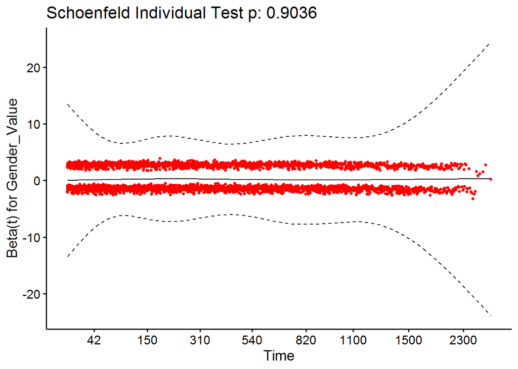

```r
ggcoxzph(resm9)[2]
```

```
## $`2`
```

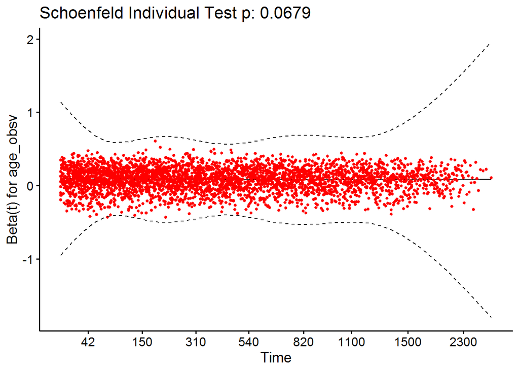

```r
ggcoxzph(resm9)[3]
```

```
## $`3`
```

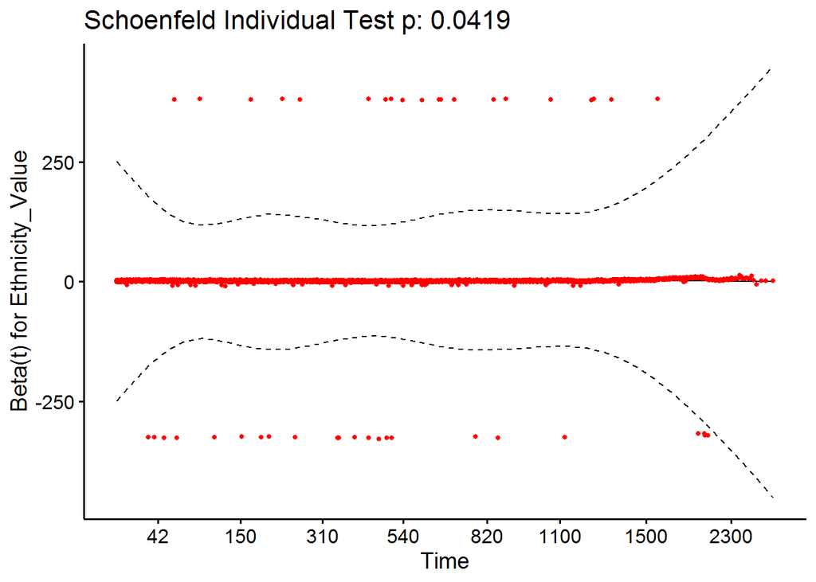

```r
anova(cox_m9)
```

```
## Analysis of Deviance Table
##  Cox model: response is Surv(time1, time2, event_death)
## Terms added sequentially (first to last)
##
##                 loglik     Chisq Df Pr(>|Chi|)
## NULL            -27681
## Gender_Value    -27680    0.2342  1     0.6284
## age_obsv        -27166 1028.7032  1     <2e-16 ***
## Ethnicity_Value -27165    2.3552  3     0.5020
## ---
## Signif. codes:  0 '***' 0.001 '**' 0.01 '*' 0.05 '.' 0.1 ' ' 1
```

**Gender, age at observation, and dementia medication class**

```r
cox_m10 <- coxph(Surv(time1, time2, event_death) ~ Gender_Value + age_obsv + type_medclass, data = all_df)

summary(cox_m10)
```

```
## Call:
## coxph(formula = Surv(time1, time2, event_death) ~ Gender_Value +
##     age_obsv + type_medclass, data = all_df)
##
##   n= 40591, number of events= 3012
##    (16033 observations deleted due to missingness)
##
##                            coef exp(coef) se(coef)      z Pr(>|z|)
## Gender_ValueMale       0.174682  1.190867 0.037679  4.636 3.55e-06 ***
## age_obsv               0.083004  1.086546 0.003076 26.988  < 2e-16 ***
## type_medclassMementine 0.666054  1.946541 0.047800 13.934  < 2e-16 ***
## ---
## Signif. codes:  0 '***' 0.001 '**' 0.01 '*' 0.05 '.' 0.1 ' ' 1
##
##                        exp(coef) exp(-coef) lower .95 upper .95
## Gender_ValueMale           1.191     0.8397     1.106     1.282
## age_obsv                   1.087     0.9203     1.080     1.093
## type_medclassMementine     1.947     0.5137     1.772     2.138
##
## Concordance= 0.667  (se = 0.006 )
## Likelihood ratio test= 947.5  on 3 df,   p=<2e-16
## Wald test            = 945.4  on 3 df,   p=<2e-16
## Score (logrank) test = 959.6  on 3 df,   p=<2e-16
```

```r
cox.zph(cox_m10)
```

```
##                 chisq df       p
## Gender_Value   0.0608  1 0.80527
## age_obsv      11.8830  1 0.00057
## type_medclass  0.6143  1 0.43316
## GLOBAL        12.8034  3 0.00508
```

```r
resm10 <- cox.zph(cox_m10)

ggcoxzph(resm10)[1]
```

```
## $`1`
```

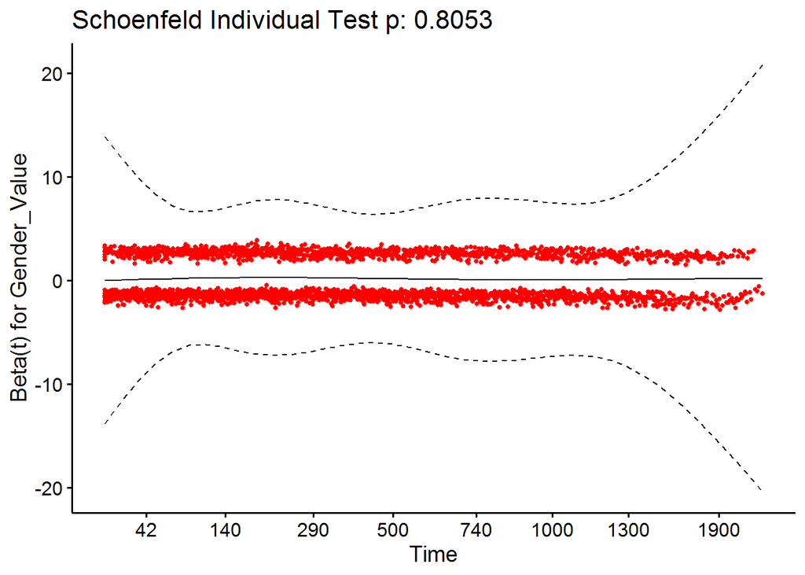

```r
ggcoxzph(resm10)[2]
```

```
## $`2`
```

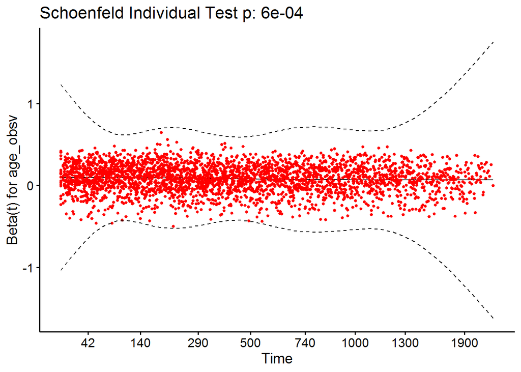

```r
ggcoxzph(resm10)[3]
```

```
## $`3`
```

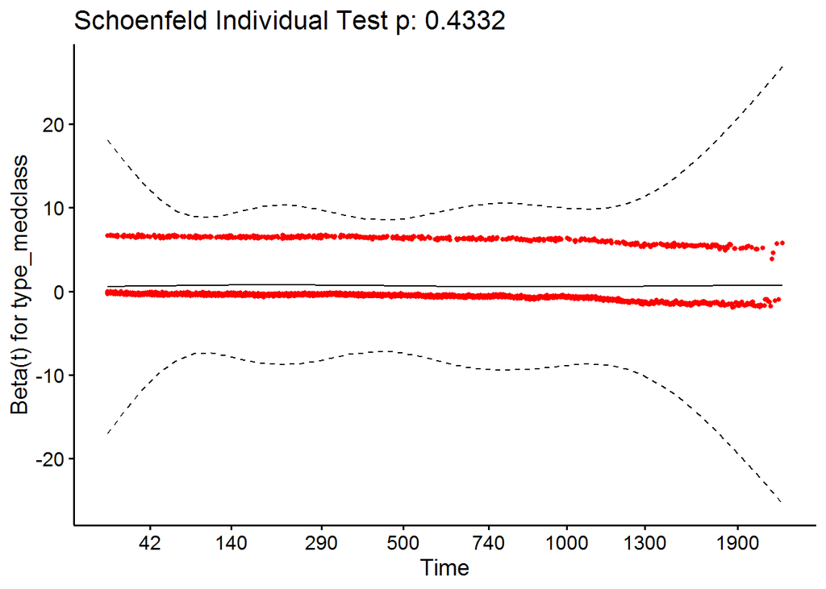

```r
anova(cox_m10)
```

```
## Analysis of Deviance Table
##  Cox model: response is Surv(time1, time2, event_death)
## Terms added sequentially (first to last)
##
##               loglik    Chisq Df Pr(>|Chi|)
## NULL          -22703
## Gender_Value  -22703   0.2336  1     0.6289
## age_obsv      -22314 778.7088  1     <2e-16 ***
## type_medclass -22230 168.5405  1     <2e-16 ***
## ---
## Signif. codes:  0 '***' 0.001 '**' 0.01 '*' 0.05 '.' 0.1 ' ' 1
```

Based on proportionality test, we removed age at observation

**Gender and dementia medication class**

```r
cox_m10a <- coxph(Surv(time1, time2, event_death) ~ Gender_Value + type_medclass, data = all_df)

summary(cox_m10a)
```

```
## Call:
## coxph(formula = Surv(time1, time2, event_death) ~ Gender_Value +
##     type_medclass, data = all_df)
##
##   n= 40591, number of events= 3012
##    (16033 observations deleted due to missingness)
##
##                           coef exp(coef) se(coef)      z Pr(>|z|)
## Gender_ValueMale       0.01853   1.01870  0.03712  0.499    0.618
## type_medclassMementine 0.68093   1.97571  0.04781 14.242   <2e-16 ***
## ---
## Signif. codes:  0 '***' 0.001 '**' 0.01 '*' 0.05 '.' 0.1 ' ' 1
##
##                        exp(coef) exp(-coef) lower .95 upper .95
## Gender_ValueMale           1.019     0.9816    0.9472     1.096
## type_medclassMementine     1.976     0.5061    1.7990     2.170
##
## Concordance= 0.536  (se = 0.006 )
## Likelihood ratio test= 175.8  on 2 df,   p=<2e-16
## Wald test            = 203.1  on 2 df,   p=<2e-16
## Score (logrank) test = 210.8  on 2 df,   p=<2e-16
```

```r
cox.zph(cox_m10a)
```

```
##               chisq df    p
## Gender_Value  0.184  1 0.67
## type_medclass 2.374  1 0.12
## GLOBAL        2.582  2 0.28
```

```r
resm10a <- cox.zph(cox_m10a)

ggcoxzph(resm10a)[1]
```

```
## $`1`
```

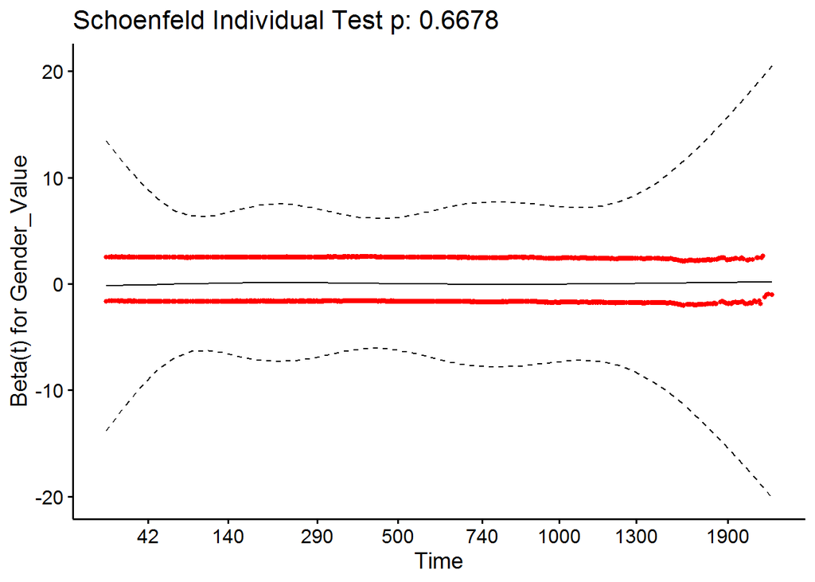

```r
ggcoxzph(resm10a)[2]
```

```
## $`2`
```

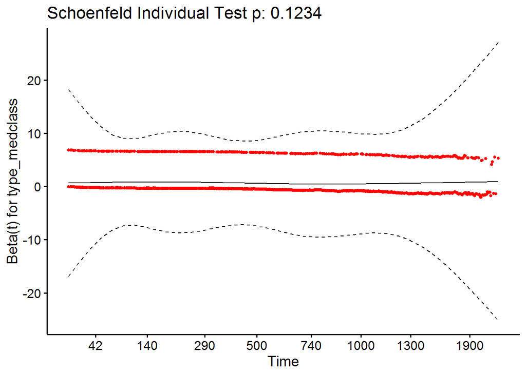

```r
anova(cox_m10)
```

```
## Analysis of Deviance Table
##  Cox model: response is Surv(time1, time2, event_death)
## Terms added sequentially (first to last)
##
##               loglik    Chisq Df Pr(>|Chi|)
## NULL          -22703
## Gender_Value  -22703   0.2336  1     0.6289
## age_obsv      -22314 778.7088  1     <2e-16 ***
## type_medclass -22230 168.5405  1     <2e-16 ***
## ---
## Signif. codes:  0 '***' 0.001 '**' 0.01 '*' 0.05 '.' 0.1 ' ' 1
```

Gender was not a significant predictor in the model above, so if we remove it we’re back to a univariate model

**Gender, age at observation, and marital_status**

```r
cox_m11 <- coxph(Surv(time1, time2, event_death) ~ Gender_Value + age_obsv + marital_status, data = all_df)

summary(cox_m11)
```

```
## Call:
## coxph(formula = Surv(time1, time2, event_death) ~ Gender_Value +
##     age_obsv + marital_status, data = all_df)
##
##   n= 34985, number of events= 2838
##    (21639 observations deleted due to missingness)
##
##                                       coef exp(coef)  se(coef)      z Pr(>|z|)
## Gender_ValueMale                  0.193832  1.213893  0.041067  4.720 2.36e-06
## age_obsv                          0.084022  1.087653  0.003177 26.444  < 2e-16
## marital_statusDivorced/Separated -0.029881  0.970561  0.107995 -0.277    0.782
## marital_statusSingle              0.083347  1.086919  0.077359  1.077    0.281
## marital_statusWidowed             0.052211  1.053598  0.044265  1.180    0.238
##
## Gender_ValueMale                 ***
## age_obsv                         ***
## marital_statusDivorced/Separated
## marital_statusSingle
## marital_statusWidowed
## ---
## Signif. codes:  0 '***' 0.001 '**' 0.01 '*' 0.05 '.' 0.1 ' ' 1
##
##                                  exp(coef) exp(-coef) lower .95 upper .95
## Gender_ValueMale                    1.2139     0.8238    1.1200     1.316
## age_obsv                            1.0877     0.9194    1.0809     1.094
## marital_statusDivorced/Separated    0.9706     1.0303    0.7854     1.199
## marital_statusSingle                1.0869     0.9200    0.9340     1.265
## marital_statusWidowed               1.0536     0.9491    0.9660     1.149
##
## Concordance= 0.657  (se = 0.006 )
## Likelihood ratio test= 837.1  on 5 df,   p=<2e-16
## Wald test            = 783  on 5 df,   p=<2e-16
## Score (logrank) test = 801.6  on 5 df,   p=<2e-16
```

```r
cox.zph(cox_m11)
```

```
##                   chisq df    p
## Gender_Value   0.000654  1 0.98
## age_obsv       2.311293  1 0.13
## marital_status 3.763005  3 0.29
## GLOBAL         5.677585  5 0.34
```

```r
resm11 <- cox.zph(cox_m11)

ggcoxzph(resm11)[1]
```

```
## $`1`
```

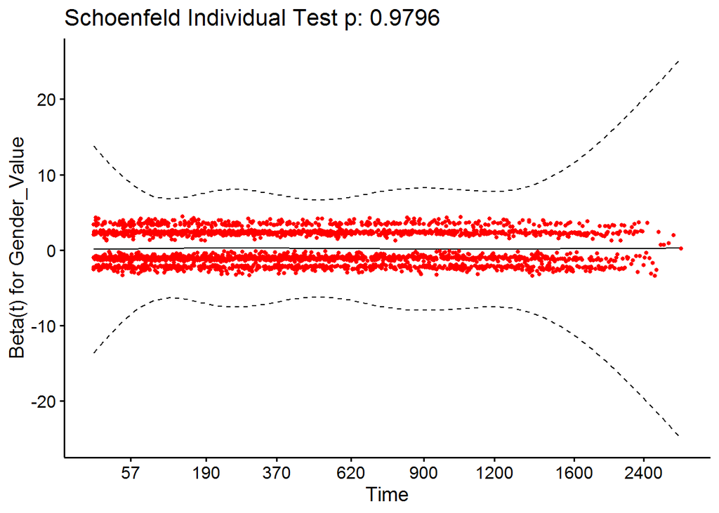

```r
ggcoxzph(resm11)[2]
```

```
## $`2`
```

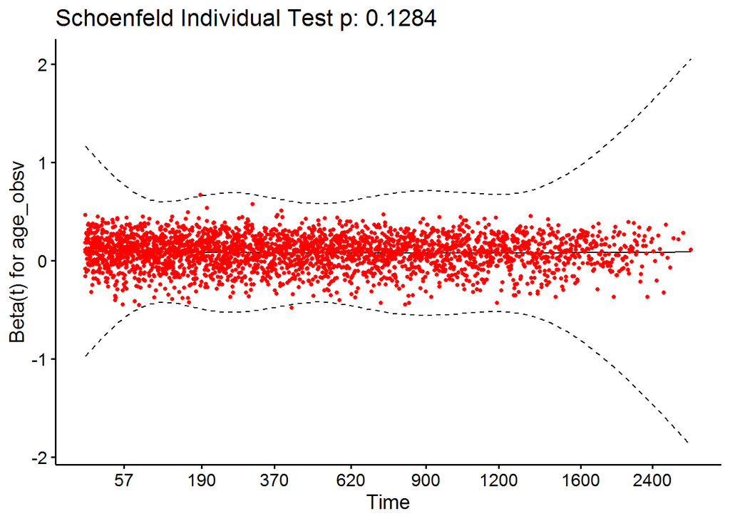

```r
ggcoxzph(resm11)[3]
```

```
## $`3`
```

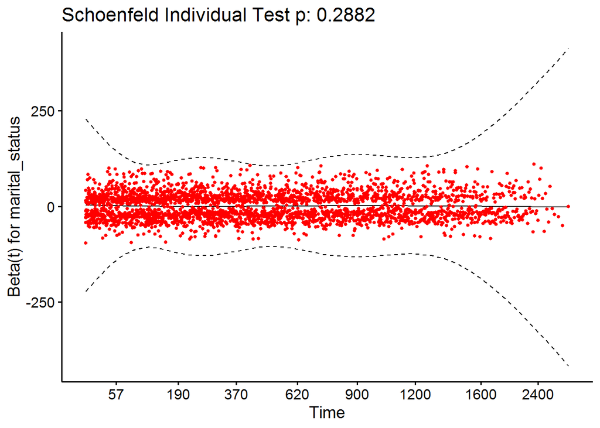

```r
anova(cox_m11)
```

```
## Analysis of Deviance Table
##  Cox model: response is Surv(time1, time2, event_death)
## Terms added sequentially (first to last)
##
##                loglik    Chisq Df Pr(>|Chi|)
## NULL           -21476
## Gender_Value   -21476   0.3039  1     0.5815
## age_obsv       -21059 834.5204  1     <2e-16 ***
## marital_status -21058   2.2775  3     0.5169
## ---
## Signif. codes:  0 '***' 0.001 '**' 0.01 '*' 0.05 '.' 0.1 ' ' 1
```

**Gender, age at observation, and type of cognitive assessment**

```r
cox_m12 <- coxph(Surv(time1, time2, event_death) ~ Gender_Value + age_obsv + type_cogeval, data = all_df)

summary(cox_m12)
```

```
## Call:
## coxph(formula = Surv(time1, time2, event_death) ~ Gender_Value +
##     age_obsv + type_cogeval, data = all_df)
##
##   n= 22963, number of events= 2275
##    (33661 observations deleted due to missingness)
##
##                      coef exp(coef) se(coef)      z Pr(>|z|)
## Gender_ValueMale 0.190632  1.210014 0.043361  4.396  1.1e-05 ***
## age_obsv         0.088410  1.092436 0.003466 25.508  < 2e-16 ***
## type_cogevalMOCA 0.059664  1.061480 0.046743  1.276    0.202
## ---
## Signif. codes:  0 '***' 0.001 '**' 0.01 '*' 0.05 '.' 0.1 ' ' 1
##
##                  exp(coef) exp(-coef) lower .95 upper .95
## Gender_ValueMale     1.210     0.8264    1.1114     1.317
## age_obsv             1.092     0.9154    1.0850     1.100
## type_cogevalMOCA     1.061     0.9421    0.9686     1.163
##
## Concordance= 0.657  (se = 0.007 )
## Likelihood ratio test= 696  on 3 df,   p=<2e-16
## Wald test            = 650.8  on 3 df,   p=<2e-16
## Score (logrank) test = 664.2  on 3 df,   p=<2e-16
```

```r
cox.zph(cox_m12)
```

```
##               chisq df    p
## Gender_Value 0.1279  1 0.72
## age_obsv     0.5761  1 0.45
## type_cogeval 0.0131  1 0.91
## GLOBAL       0.6322  3 0.89
```

```r
resm12 <- cox.zph(cox_m12)

ggcoxzph(resm12)[1]
```

```
## $`1`
```

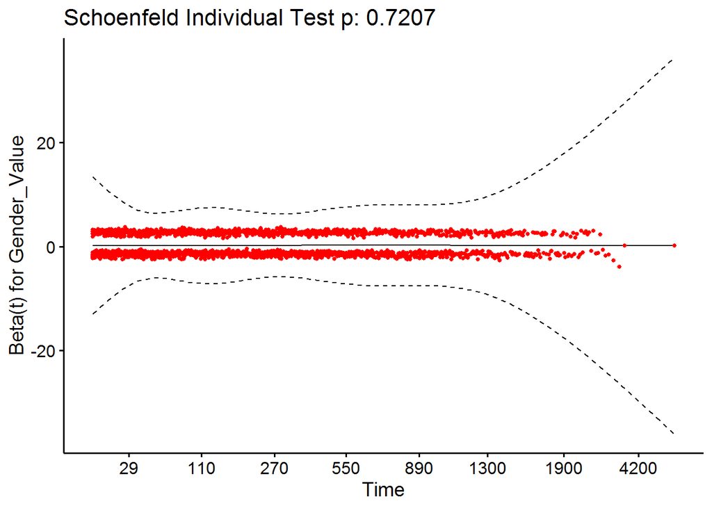

```r
ggcoxzph(resm12)[2]
```

```
## $`2`
```

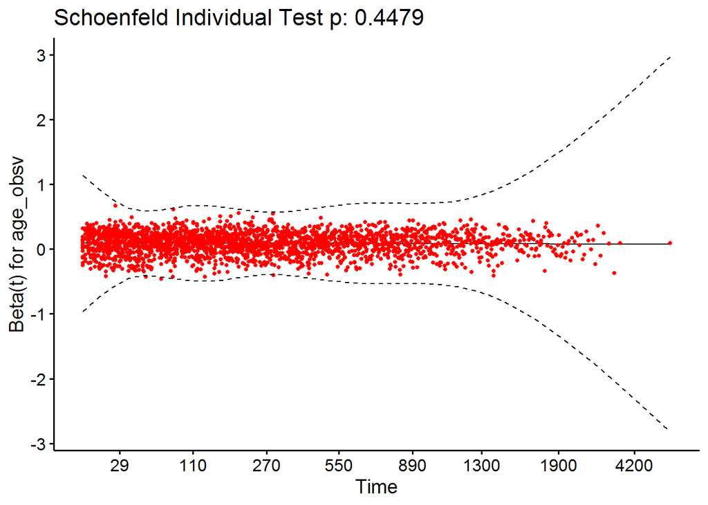

```r
ggcoxzph(resm12)[3]
```

```
## $`3`
```

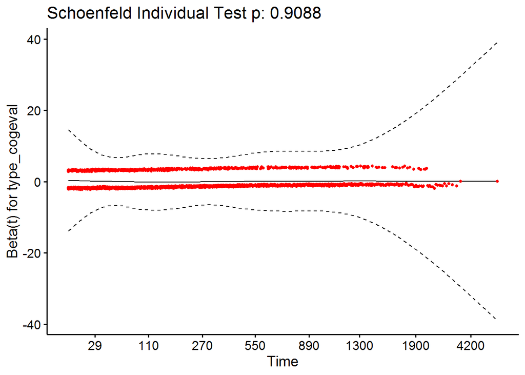

```r
anova(cox_m12)
```

```
## Analysis of Deviance Table
##  Cox model: response is Surv(time1, time2, event_death)
## Terms added sequentially (first to last)
##
##              loglik    Chisq Df Pr(>|Chi|)
## NULL         -17238
## Gender_Value -17238   0.2559  1     0.6129
## age_obsv     -16891 694.0893  1     <2e-16 ***
## type_cogeval -16890   1.6164  1     0.2036
## ---
## Signif. codes:  0 '***' 0.001 '**' 0.01 '*' 0.05 '.' 0.1 ' ' 1
```

**Gender, age at observation, and score in cognitive assessment**

```r
cox_m13 <- coxph(Surv(time1, time2, event_death) ~ Gender_Value + age_obsv + numerator, data = all_df)

summary(cox_m13)
```

```
## Call:
## coxph(formula = Surv(time1, time2, event_death) ~ Gender_Value +
##     age_obsv + numerator, data = all_df)
##
##   n= 22963, number of events= 2275
##    (33661 observations deleted due to missingness)
##
##                       coef exp(coef)  se(coef)       z Pr(>|z|)
## Gender_ValueMale  0.212708  1.237023  0.043308   4.912 9.04e-07 ***
## age_obsv          0.084718  1.088410  0.003459  24.494  < 2e-16 ***
## numerator        -0.040536  0.960275  0.002947 -13.753  < 2e-16 ***
## ---
## Signif. codes:  0 '***' 0.001 '**' 0.01 '*' 0.05 '.' 0.1 ' ' 1
##
##                  exp(coef) exp(-coef) lower .95 upper .95
## Gender_ValueMale    1.2370     0.8084    1.1364    1.3466
## age_obsv            1.0884     0.9188    1.0811    1.0958
## numerator           0.9603     1.0414    0.9547    0.9658
##
## Concordance= 0.674  (se = 0.007 )
## Likelihood ratio test= 873.4  on 3 df,   p=<2e-16
## Wald test            = 831.9  on 3 df,   p=<2e-16
## Score (logrank) test = 843.6  on 3 df,   p=<2e-16
```

```r
cox.zph(cox_m13)
```

```
##                chisq df    p
## Gender_Value 0.00154  1 0.97
## age_obsv     0.78222  1 0.38
## numerator    0.98525  1 0.32
## GLOBAL       1.96219  3 0.58
```

```r
resm13 <- cox.zph(cox_m13)

ggcoxzph(resm13)[1]
```

```
## $`1`
```

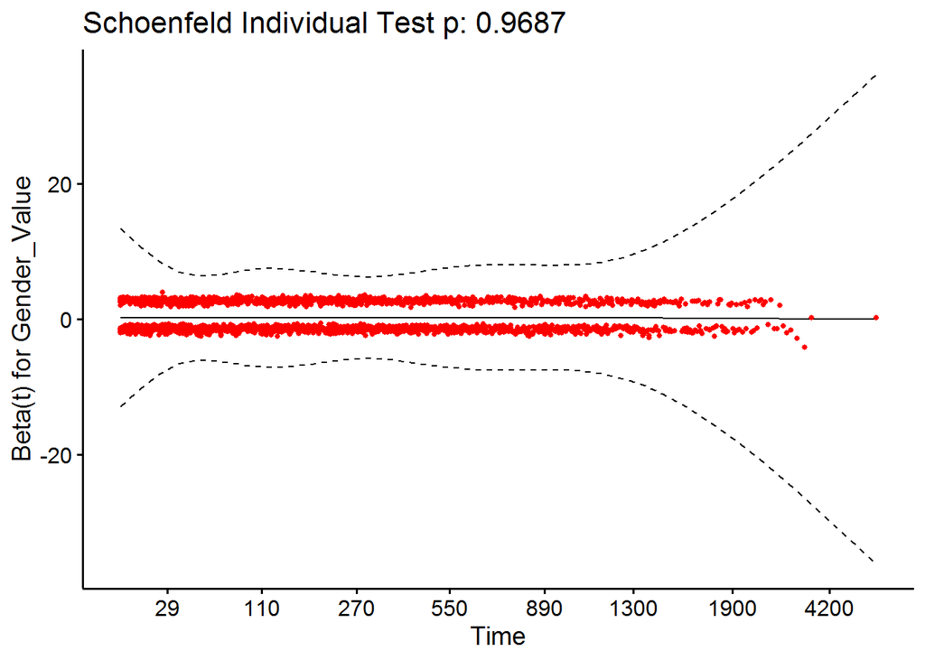

```r
ggcoxzph(resm13)[2]
```

```
## $`2`
```

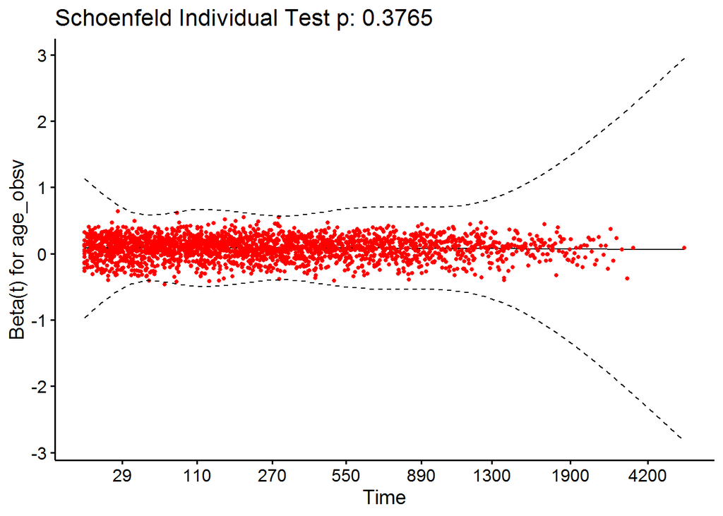

```r
ggcoxzph(resm13)[3]
```

```
## $`3`
```

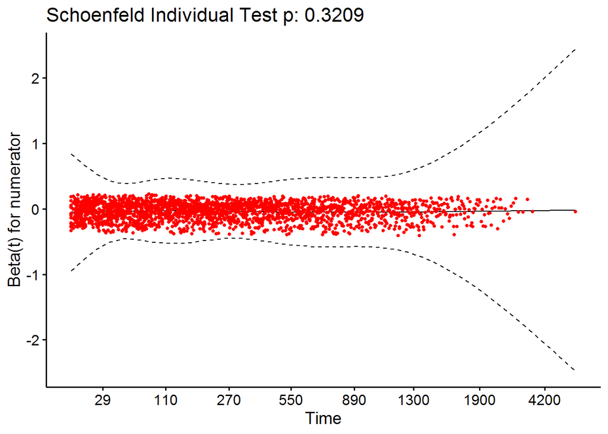

```r
anova(cox_m13)
```

```
## Analysis of Deviance Table
##  Cox model: response is Surv(time1, time2, event_death)
## Terms added sequentially (first to last)
##
##              loglik    Chisq Df Pr(>|Chi|)
## NULL         -17238
## Gender_Value -17238   0.2559  1     0.6129
## age_obsv     -16891 694.0893  1     <2e-16 ***
## numerator    -16801 179.0377  1     <2e-16 ***
## ---
## Signif. codes:  0 '***' 0.001 '**' 0.01 '*' 0.05 '.' 0.1 ' ' 1
```

*Forest plot*

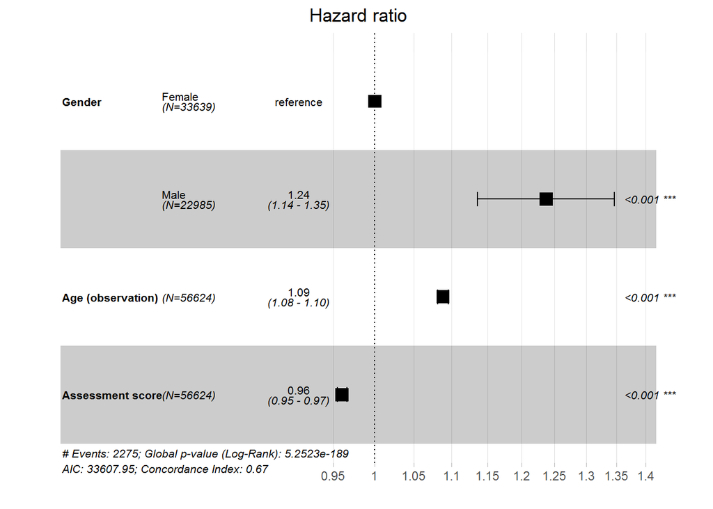

```r
forest_df13 <- all_df %>%
  transmute(time1,
            time2,
            event_death,
            Gender = factor(Gender_Value),
            `Age (observation)` = age_obsv,
            `Assessment score` = numerator) %>%
  mutate(Gender = relevel(Gender, ref = "Female"))

new13 <- coxph(Surv(time1, time2, event_death) ~ Gender + `Age (observation)` + `Assessment score`, data = forest_df13)

ggforest(new13,
         cpositions = c(0.003, 0.17, 0.4))
```

**Gender, age at observation, and chronic medication use**

```r
cox_m14 <- coxph(Surv(time1, time2, event_death) ~ Gender_Value + age_obsv + medother_grouped, data = all_df)

summary(cox_m14)
```

```
## Call:
## coxph(formula = Surv(time1, time2, event_death) ~ Gender_Value +
##     age_obsv + medother_grouped, data = all_df)
##
##   n= 16188, number of events= 1129
##    (40436 observations deleted due to missingness)
##
##                                coef exp(coef)  se(coef)      z Pr(>|z|)
## Gender_ValueMale           0.351644  1.421403  0.062217  5.652 1.59e-08 ***
## age_obsv                   0.070782  1.073347  0.004651 15.220  < 2e-16 ***
## medother_groupedInsulin   -0.248256  0.780160  0.167902 -1.479 0.139254
## medother_groupedSNRIs     -0.538975  0.583346  0.220563 -2.444 0.014540 *
## medother_groupedSSRIs     -0.329472  0.719304  0.079132 -4.164 3.13e-05 ***
## medother_groupedTCAs      -0.560911  0.570689  0.185921 -3.017 0.002553 **
## medother_groupedTeCAs     -0.347772  0.706260  0.101466 -3.427 0.000609 ***
## medother_groupedTrazodone  0.063842  1.065924  0.084040  0.760 0.447455
## ---
## Signif. codes:  0 '***' 0.001 '**' 0.01 '*' 0.05 '.' 0.1 ' ' 1
##
##                           exp(coef) exp(-coef) lower .95 upper .95
## Gender_ValueMale             1.4214     0.7035    1.2582    1.6057
## age_obsv                     1.0733     0.9317    1.0636    1.0832
## medother_groupedInsulin      0.7802     1.2818    0.5614    1.0842
## medother_groupedSNRIs        0.5833     1.7142    0.3786    0.8988
## medother_groupedSSRIs        0.7193     1.3902    0.6160    0.8400
## medother_groupedTCAs         0.5707     1.7523    0.3964    0.8216
## medother_groupedTeCAs        0.7063     1.4159    0.5789    0.8617
## medother_groupedTrazodone    1.0659     0.9382    0.9040    1.2568
##
## Concordance= 0.652  (se = 0.01 )
## Likelihood ratio test= 307  on 8 df,   p=<2e-16
## Wald test            = 297.2  on 8 df,   p=<2e-16
## Score (logrank) test = 301.4  on 8 df,   p=<2e-16
```

```r
cox.zph(cox_m14)
```

```
##                  chisq df    p
## Gender_Value     1.309  1 0.25
## age_obsv         0.262  1 0.61
## medother_grouped 6.145  6 0.41
## GLOBAL           7.733  8 0.46
```

```r
resm14 <- cox.zph(cox_m14)

ggcoxzph(resm14)[1]
```

```
## $`1`
```

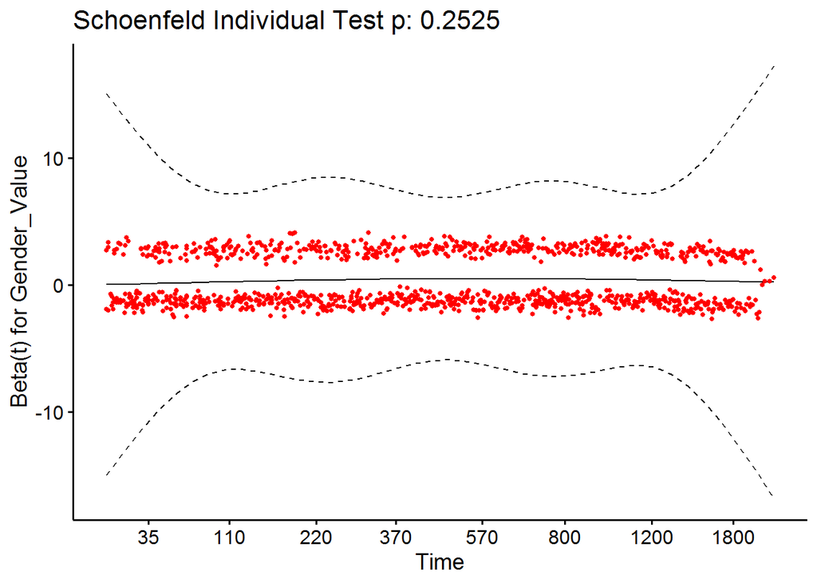

```r
ggcoxzph(resm14)[2]
```

```
## $`2`
```

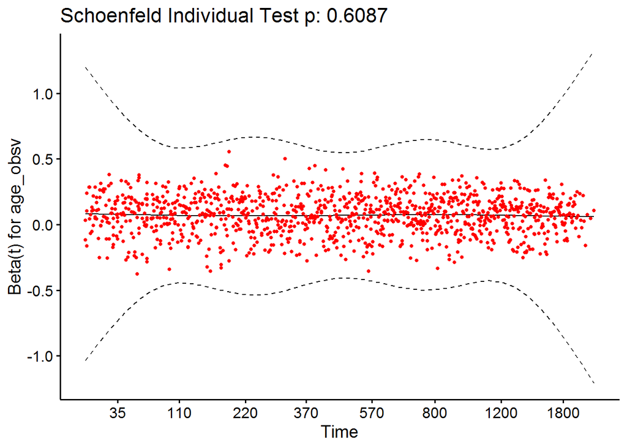

```r
ggcoxzph(resm14)[3]
```

```
## $`3`
```

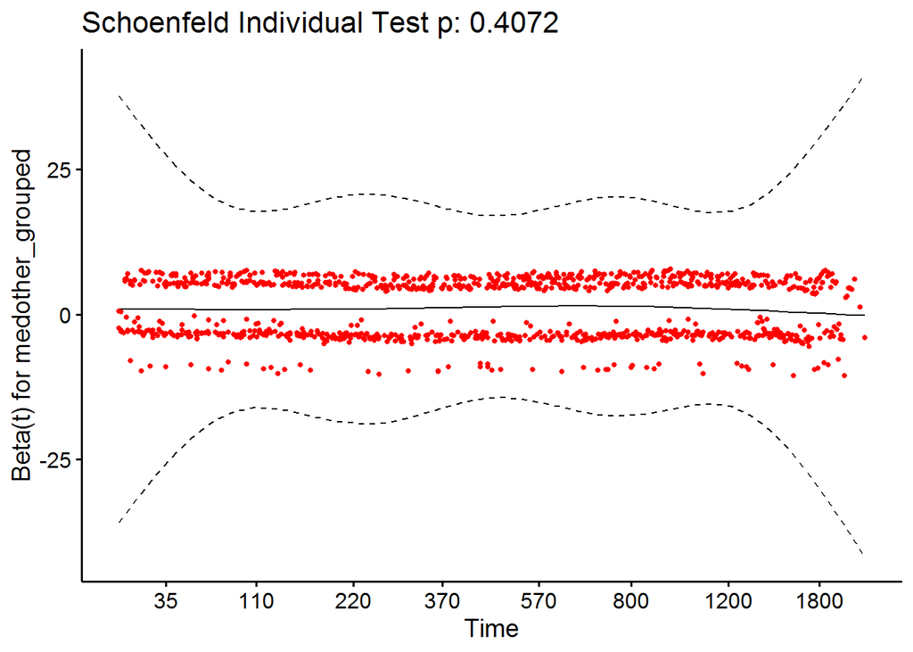

```r
anova(cox_m14)
```

```
## Analysis of Deviance Table
##  Cox model: response is Surv(time1, time2, event_death)
## Terms added sequentially (first to last)
##
##                   loglik   Chisq Df Pr(>|Chi|)
## NULL             -6923.7
## Gender_Value     -6918.4  10.650  1   0.001101 **
## age_obsv         -6792.0 252.702  1  < 2.2e-16 ***
## medother_grouped -6770.2  43.638  6   8.72e-08 ***
## ---
## Signif. codes:  0 '***' 0.001 '**' 0.01 '*' 0.05 '.' 0.1 ' ' 1
```

*Forest plot*

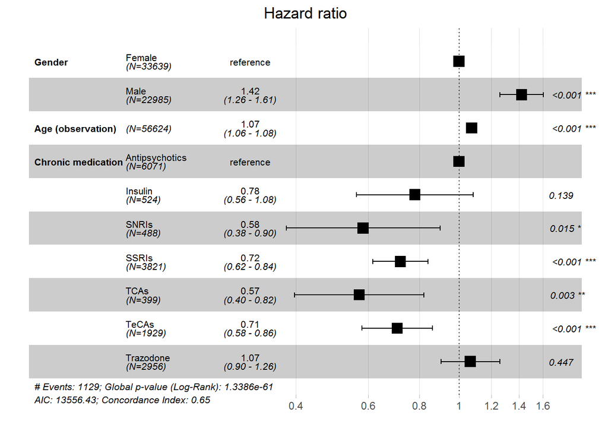

```r
forest_df14 <- all_df %>%
  transmute(time1,
            time2,
            event_death,
            Gender = factor(Gender_Value),
            `Age (observation)` = age_obsv,
            `Chronic medication` = medother_grouped) %>%
  mutate(Gender = relevel(Gender, ref = "Female"))

new14 <- coxph(Surv(time1, time2, event_death) ~ Gender + `Age (observation)` + `Chronic medication`, data = forest_df14)

ggforest(new14,
         cpositions = c(0.01, 0.175, 0.4))
```

**Gender, age at observation, marital status, and score in cognitive assessment**

```r
cox_m15 <- coxph(Surv(time1, time2, event_death) ~ Gender_Value + age_obsv + marital_status + numerator, data = all_df)

summary(cox_m15)
```

```
## Call:
## coxph(formula = Surv(time1, time2, event_death) ~ Gender_Value +
##     age_obsv + marital_status + numerator, data = all_df)
##
##   n= 13954, number of events= 1221
##    (42670 observations deleted due to missingness)
##
##                                       coef exp(coef)  se(coef)      z Pr(>|z|)
## Gender_ValueMale                  0.234671  1.264492  0.063484  3.697 0.000219
## age_obsv                          0.084894  1.088602  0.005017 16.921  < 2e-16
## marital_statusDivorced/Separated  0.226134  1.253744  0.160458  1.409 0.158746
## marital_statusSingle              0.357779  1.430149  0.115056  3.110 0.001873
## marital_statusWidowed             0.169772  1.185035  0.068487  2.479 0.013179
## numerator                        -0.041052  0.959779  0.004176 -9.831  < 2e-16
##
## Gender_ValueMale                 ***
## age_obsv                         ***
## marital_statusDivorced/Separated
## marital_statusSingle             **
## marital_statusWidowed            *
## numerator                        ***
## ---
## Signif. codes:  0 '***' 0.001 '**' 0.01 '*' 0.05 '.' 0.1 ' ' 1
##
##                                  exp(coef) exp(-coef) lower .95 upper .95
## Gender_ValueMale                    1.2645     0.7908    1.1166    1.4320
## age_obsv                            1.0886     0.9186    1.0779    1.0994
## marital_statusDivorced/Separated    1.2537     0.7976    0.9154    1.7171
## marital_statusSingle                1.4301     0.6992    1.1414    1.7919
## marital_statusWidowed               1.1850     0.8439    1.0362    1.3553
## numerator                           0.9598     1.0419    0.9520    0.9677
##
## Concordance= 0.679  (se = 0.009 )
## Likelihood ratio test= 495.6  on 6 df,   p=<2e-16
## Wald test            = 469.5  on 6 df,   p=<2e-16
## Score (logrank) test = 480.8  on 6 df,   p=<2e-16
```

```r
cox.zph(cox_m15)
```

```
##                chisq df    p
## Gender_Value   0.746  1 0.39
## age_obsv       1.603  1 0.21
## marital_status 0.921  3 0.82
## numerator      0.598  1 0.44
## GLOBAL         4.649  6 0.59
```

```r
resm15 <- cox.zph(cox_m15)

ggcoxzph(resm15)[1]
```

```
## $`1`
```

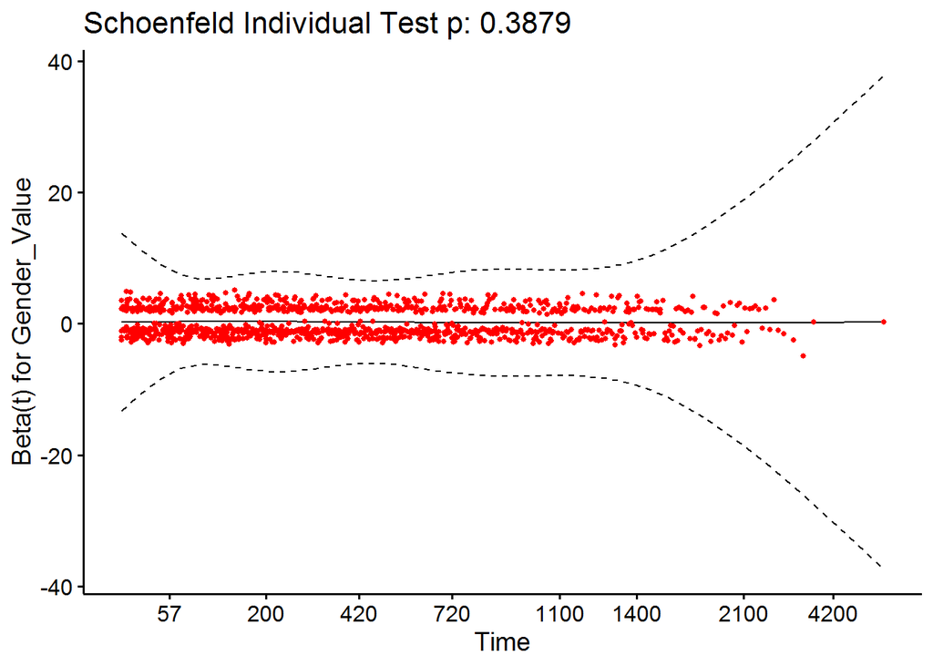

```r
ggcoxzph(resm15)[2]
```

```
## $`2`
```

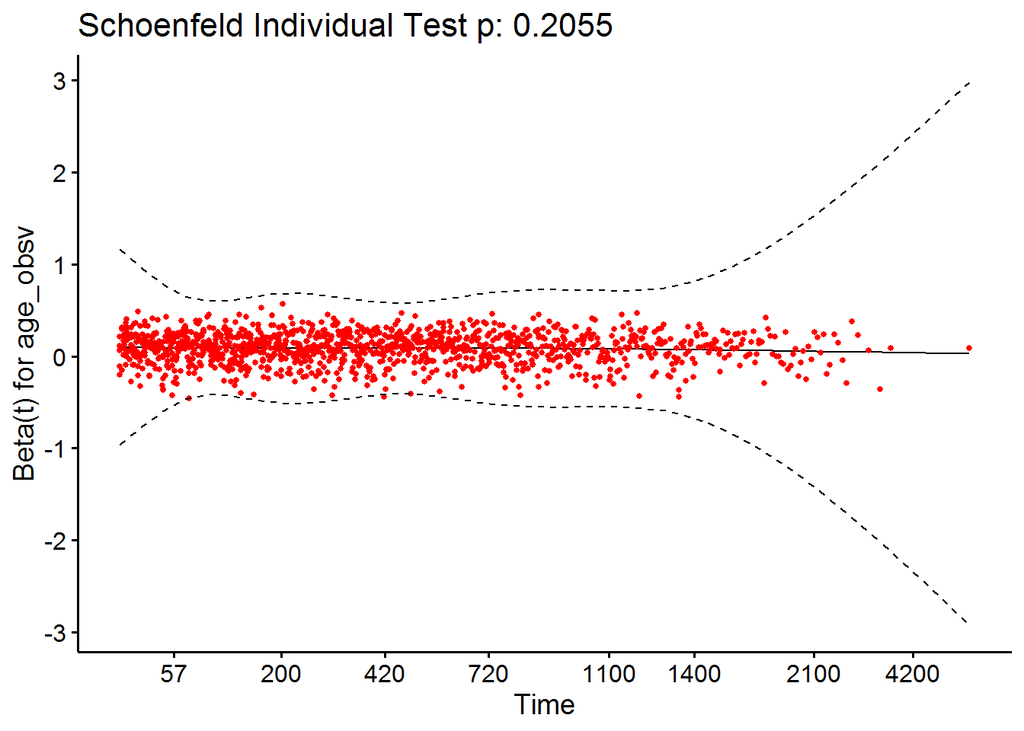

```r
ggcoxzph(resm15)[3]
```

```
## $`3`
```

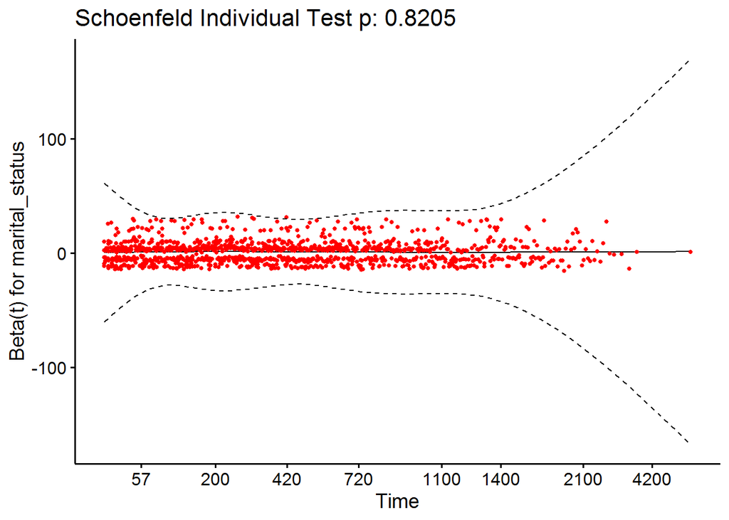

```r
ggcoxzph(resm15)[4]
```

```
## $`4`
```

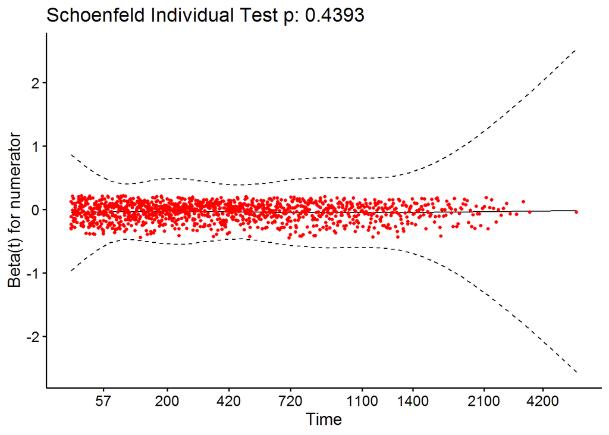

```r
anova(cox_m15)
```

```
## Analysis of Deviance Table
##  Cox model: response is Surv(time1, time2, event_death)
## Terms added sequentially (first to last)
##
##                 loglik    Chisq Df Pr(>|Chi|)
## NULL           -8467.2
## Gender_Value   -8467.1   0.2891  1    0.59082
## age_obsv       -8270.3 393.5142  1    < 2e-16 ***
## marital_status -8265.0  10.7045  3    0.01344 *
## numerator      -8219.4  91.0662  1    < 2e-16 ***
## ---
## Signif. codes:  0 '***' 0.001 '**' 0.01 '*' 0.05 '.' 0.1 ' ' 1
```

*Forest plot*

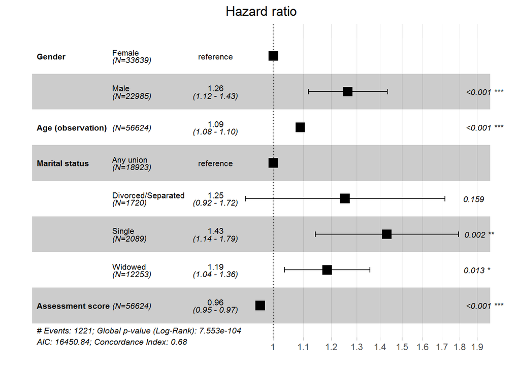

```r
forest_df15 <- all_df %>%
  transmute(time1,
            time2,
            event_death,
            Gender = factor(Gender_Value),
            `Age (observation)` = age_obsv,
            `Marital status` = marital_status,
            `Assessment score` = numerator) %>%
  mutate(Gender = relevel(Gender, ref = "Female"))

new15 <- coxph(Surv(time1, time2, event_death) ~ Gender + `Age (observation)` + `Marital status` + `Assessment score`, data = forest_df15)

ggforest(new15,
         cpositions = c(0.01, 0.175, 0.4))
```

**Gender, age at observation, marital status, and chronic medication use**

```r
cox_m16 <- coxph(Surv(time1, time2, event_death) ~  Gender_Value + age_obsv + marital_status + medother_grouped, data = all_df)

summary(cox_m16)
```

```
## Call:
## coxph(formula = Surv(time1, time2, event_death) ~ Gender_Value +
##     age_obsv + marital_status + medother_grouped, data = all_df)
##
##   n= 10104, number of events= 646
##    (46520 observations deleted due to missingness)
##
##                                       coef exp(coef)  se(coef)      z Pr(>|z|)
## Gender_ValueMale                  0.386695  1.472108  0.086843  4.453 8.48e-06
## age_obsv                          0.065556  1.067753  0.006639  9.875  < 2e-16
## marital_statusDivorced/Separated -0.194442  0.823294  0.222603 -0.873  0.38239
## marital_statusSingle              0.130207  1.139064  0.165325  0.788  0.43094
## marital_statusWidowed             0.065591  1.067790  0.093937  0.698  0.48502
## medother_groupedInsulin          -0.421500  0.656062  0.262493 -1.606  0.10833
## medother_groupedSNRIs            -0.502985  0.604723  0.311879 -1.613  0.10680
## medother_groupedSSRIs            -0.294913  0.744596  0.109308 -2.698  0.00698
## medother_groupedTCAs             -0.405125  0.666893  0.227818 -1.778  0.07536
## medother_groupedTeCAs            -0.239469  0.787045  0.131113 -1.826  0.06778
## medother_groupedTrazodone         0.191976  1.211642  0.109512  1.753  0.07960
##
## Gender_ValueMale                 ***
## age_obsv                         ***
## marital_statusDivorced/Separated
## marital_statusSingle
## marital_statusWidowed
## medother_groupedInsulin
## medother_groupedSNRIs
## medother_groupedSSRIs            **
## medother_groupedTCAs             .
## medother_groupedTeCAs            .
## medother_groupedTrazodone        .
## ---
## Signif. codes:  0 '***' 0.001 '**' 0.01 '*' 0.05 '.' 0.1 ' ' 1
##
##                                  exp(coef) exp(-coef) lower .95 upper .95
## Gender_ValueMale                    1.4721     0.6793    1.2417    1.7453
## age_obsv                            1.0678     0.9365    1.0539    1.0817
## marital_statusDivorced/Separated    0.8233     1.2146    0.5322    1.2736
## marital_statusSingle                1.1391     0.8779    0.8238    1.5750
## marital_statusWidowed               1.0678     0.9365    0.8882    1.2836
## medother_groupedInsulin             0.6561     1.5242    0.3922    1.0974
## medother_groupedSNRIs               0.6047     1.6537    0.3282    1.1144
## medother_groupedSSRIs               0.7446     1.3430    0.6010    0.9225
## medother_groupedTCAs                0.6669     1.4995    0.4267    1.0423
## medother_groupedTeCAs               0.7870     1.2706    0.6087    1.0177
## medother_groupedTrazodone           1.2116     0.8253    0.9776    1.5017
##
## Concordance= 0.651  (se = 0.013 )
## Likelihood ratio test= 172.5  on 11 df,   p=<2e-16
## Wald test            = 167.1  on 11 df,   p=<2e-16
## Score (logrank) test = 169.9  on 11 df,   p=<2e-16
```

```r
cox.zph(cox_m16)
```

```
##                   chisq df    p
## Gender_Value     0.0536  1 0.82
## age_obsv         0.3712  1 0.54
## marital_status   0.5572  3 0.91
## medother_grouped 7.5394  6 0.27
## GLOBAL           8.3017 11 0.69
```

```r
resm16 <- cox.zph(cox_m16)

ggcoxzph(resm16)[1]
```

```
## $`1`
```

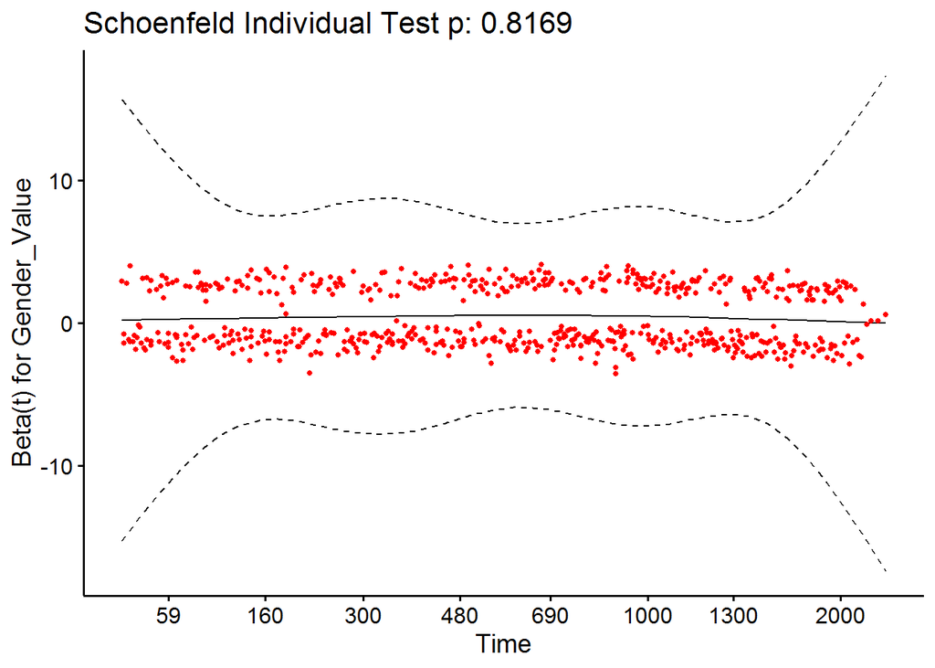

```r
ggcoxzph(resm16)[2]
```

```
## $`2`
```

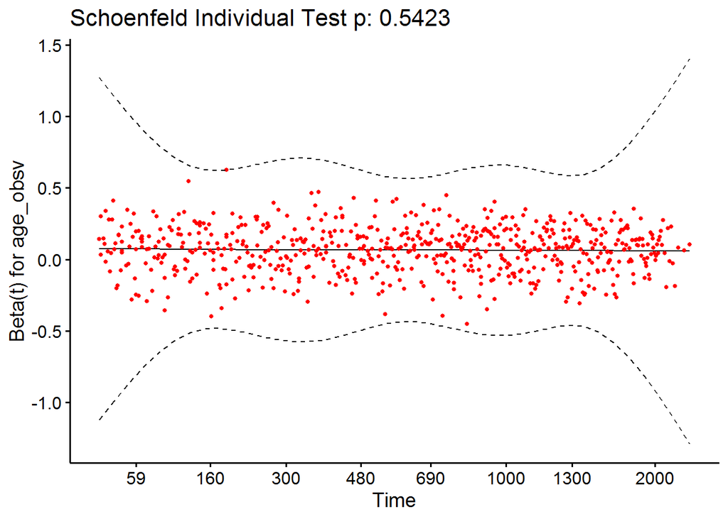

```r
ggcoxzph(resm16)[3]
```

```
## $`3`
```

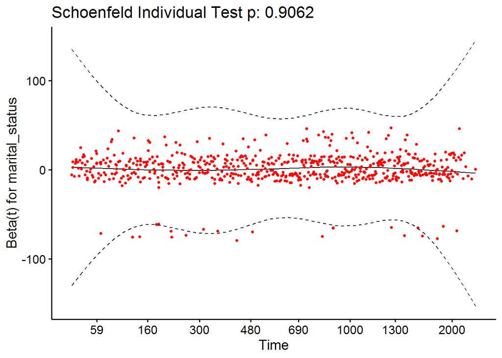

```r
ggcoxzph(resm16)[4]
```

```
## $`4`
```

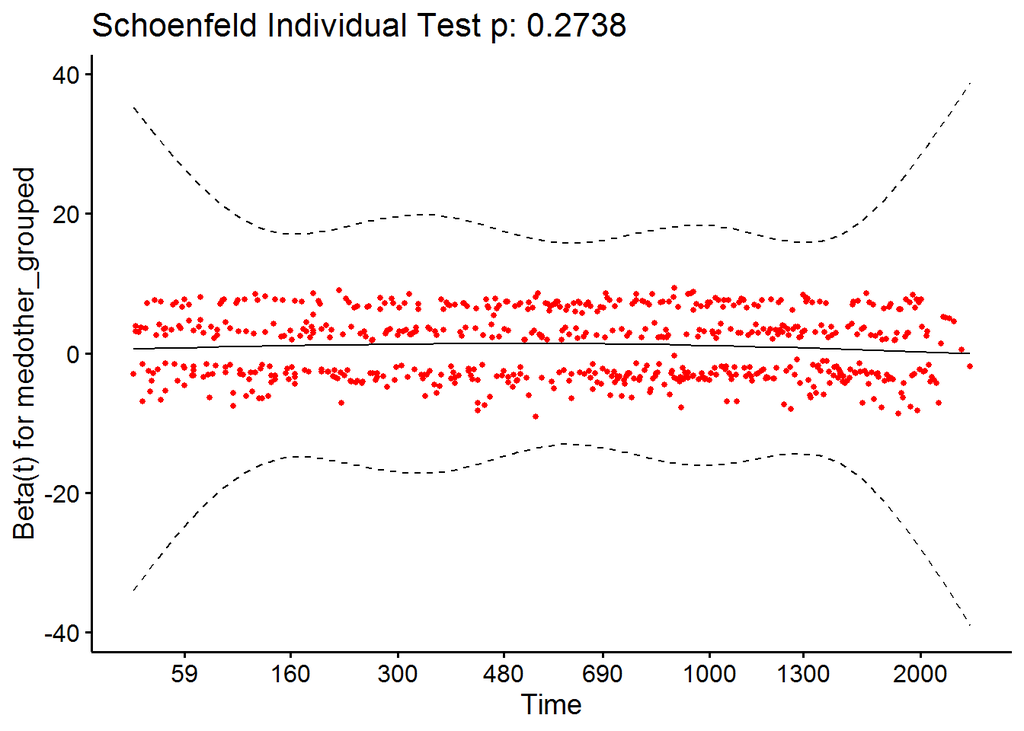

```r
anova(cox_m16)
```

```
## Analysis of Deviance Table
##  Cox model: response is Surv(time1, time2, event_death)
## Terms added sequentially (first to last)
##
##                   loglik    Chisq Df Pr(>|Chi|)
## NULL             -3593.9
## Gender_Value     -3589.9   7.9915  1     0.0047 **
## age_obsv         -3523.2 133.2447  1  < 2.2e-16 ***
## marital_status   -3521.9   2.6650  3     0.4462
## medother_grouped -3507.6  28.6102  6  7.209e-05 ***
## ---
## Signif. codes:  0 '***' 0.001 '**' 0.01 '*' 0.05 '.' 0.1 ' ' 1
```

If remove marital status, we’re back to Gender, age at observation, and chronic medication (i.e., cox_m14)…

But we could try: **Age at observation, chronic medication, and marital_status**

```r
cox_m16a <- coxph(Surv(time1, time2, event_death) ~ age_obsv + marital_status + medother_grouped, data = all_df)

summary(cox_m16a)
```

```
## Call:
## coxph(formula = Surv(time1, time2, event_death) ~ age_obsv +
##     marital_status + medother_grouped, data = all_df)
##
##   n= 10104, number of events= 646
##    (46520 observations deleted due to missingness)
##
##                                       coef exp(coef)  se(coef)      z Pr(>|z|)
## age_obsv                          0.062301  1.064282  0.006575  9.476  < 2e-16
## marital_statusDivorced/Separated -0.275558  0.759149  0.221939 -1.242  0.21439
## marital_statusSingle              0.079781  1.083049  0.164970  0.484  0.62867
## marital_statusWidowed            -0.054845  0.946632  0.089926 -0.610  0.54193
## medother_groupedInsulin          -0.412786  0.661804  0.262525 -1.572  0.11587
## medother_groupedSNRIs            -0.512610  0.598930  0.311864 -1.644  0.10024
## medother_groupedSSRIs            -0.319584  0.726451  0.109048 -2.931  0.00338
## medother_groupedTCAs             -0.466979  0.626893  0.227299 -2.054  0.03993
## medother_groupedTeCAs            -0.246339  0.781658  0.130959 -1.881  0.05997
## medother_groupedTrazodone         0.206614  1.229508  0.109264  1.891  0.05863
##
## age_obsv                         ***
## marital_statusDivorced/Separated
## marital_statusSingle
## marital_statusWidowed
## medother_groupedInsulin
## medother_groupedSNRIs
## medother_groupedSSRIs            **
## medother_groupedTCAs             *
## medother_groupedTeCAs            .
## medother_groupedTrazodone        .
## ---
## Signif. codes:  0 '***' 0.001 '**' 0.01 '*' 0.05 '.' 0.1 ' ' 1
##
##                                  exp(coef) exp(-coef) lower .95 upper .95
## age_obsv                            1.0643     0.9396    1.0507    1.0781
## marital_statusDivorced/Separated    0.7591     1.3173    0.4914    1.1728
## marital_statusSingle                1.0830     0.9233    0.7838    1.4965
## marital_statusWidowed               0.9466     1.0564    0.7937    1.1291
## medother_groupedInsulin             0.6618     1.5110    0.3956    1.1071
## medother_groupedSNRIs               0.5989     1.6696    0.3250    1.1037
## medother_groupedSSRIs               0.7265     1.3766    0.5867    0.8996
## medother_groupedTCAs                0.6269     1.5952    0.4015    0.9787
## medother_groupedTeCAs               0.7817     1.2793    0.6047    1.0104
## medother_groupedTrazodone           1.2295     0.8133    0.9925    1.5231
##
## Concordance= 0.645  (se = 0.013 )
## Likelihood ratio test= 152.9  on 10 df,   p=<2e-16
## Wald test            = 150.2  on 10 df,   p=<2e-16
## Score (logrank) test = 152.7  on 10 df,   p=<2e-16
```

```r
cox.zph(cox_m16a)
```

```
##                  chisq df    p
## age_obsv         0.263  1 0.61
## marital_status   0.555  3 0.91
## medother_grouped 7.903  6 0.25
## GLOBAL           8.361 10 0.59
```

```r
resm16a <- cox.zph(cox_m16a)

ggcoxzph(resm16a)[1]
```

```
## $`1`
```

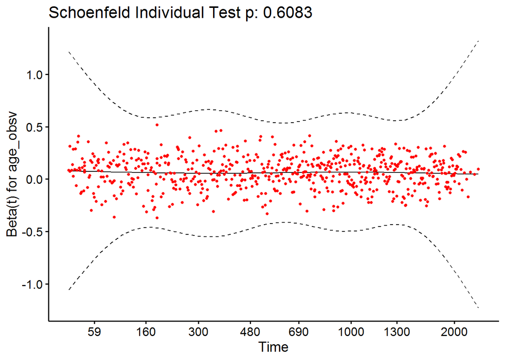

```r
ggcoxzph(resm16a)[2]
```

```
## $`2`
```

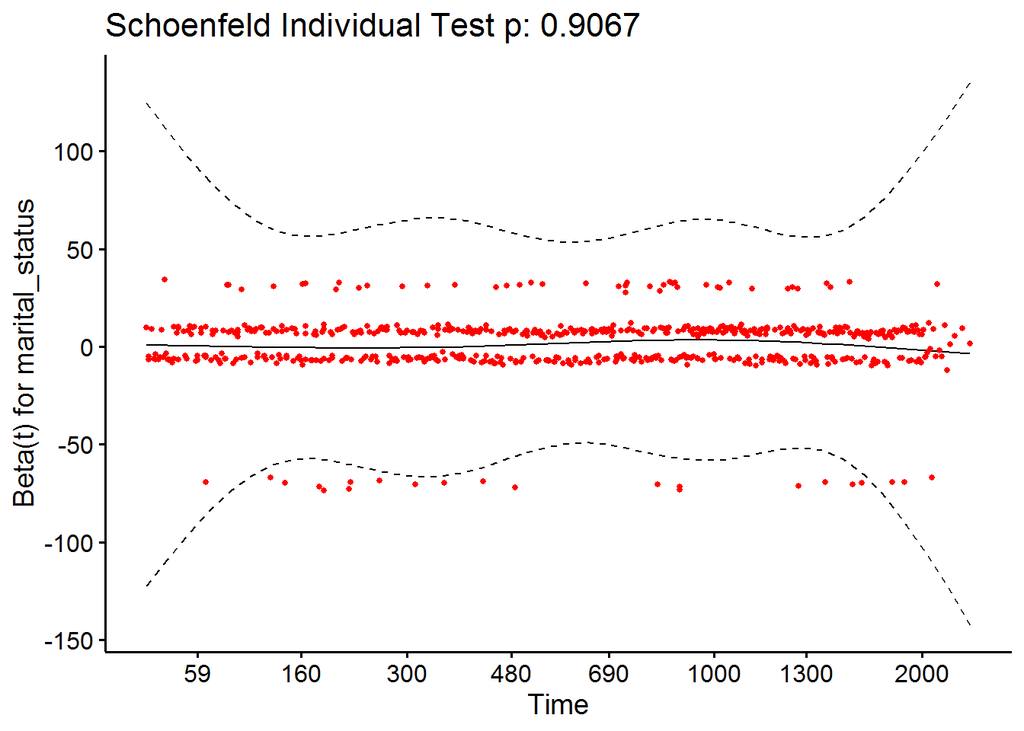

```r
ggcoxzph(resm16a)[3]
```

```
## $`3`
```

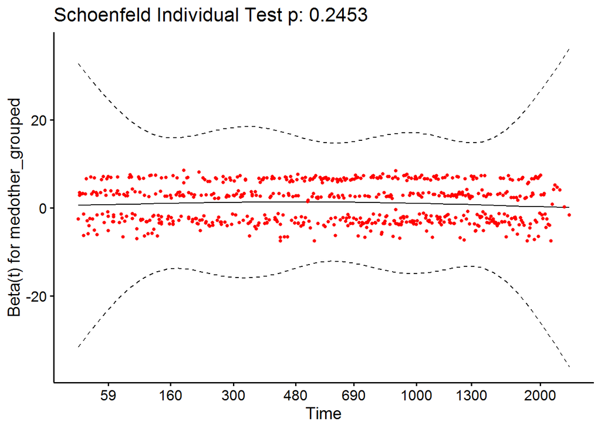

```r
anova(cox_m16a)
```

```
## Analysis of Deviance Table
##  Cox model: response is Surv(time1, time2, event_death)
## Terms added sequentially (first to last)
##
##                   loglik    Chisq Df Pr(>|Chi|)
## NULL             -3593.9
## age_obsv         -3535.5 116.6706  1  < 2.2e-16 ***
## marital_status   -3533.9   3.3119  3      0.346
## medother_grouped -3517.4  32.9682  6  1.063e-05 ***
## ---
## Signif. codes:  0 '***' 0.001 '**' 0.01 '*' 0.05 '.' 0.1 ' ' 1
```

We removed marital status because it was not a significant covariate in model

**Age at observation and chronic medication**

```r
cox_m16b <- coxph(Surv(time1, time2, event_death) ~ age_obsv + medother_grouped, data = all_df)

summary(cox_m16b)
```

```
## Call:
## coxph(formula = Surv(time1, time2, event_death) ~ age_obsv +
##     medother_grouped, data = all_df)
##
##   n= 16188, number of events= 1129
##    (40436 observations deleted due to missingness)
##
##                                coef exp(coef)  se(coef)      z Pr(>|z|)
## age_obsv                   0.065593  1.067792  0.004519 14.515  < 2e-16 ***
## medother_groupedInsulin   -0.247627  0.780651  0.167911 -1.475 0.140279
## medother_groupedSNRIs     -0.556150  0.573412  0.220519 -2.522 0.011669 *
## medother_groupedSSRIs     -0.340245  0.711596  0.079112 -4.301  1.7e-05 ***
## medother_groupedTCAs      -0.618116  0.538959  0.185618 -3.330 0.000868 ***
## medother_groupedTeCAs     -0.351040  0.703956  0.101424 -3.461 0.000538 ***
## medother_groupedTrazodone  0.076968  1.080008  0.083980  0.917 0.359400
## ---
## Signif. codes:  0 '***' 0.001 '**' 0.01 '*' 0.05 '.' 0.1 ' ' 1
##
##                           exp(coef) exp(-coef) lower .95 upper .95
## age_obsv                     1.0678     0.9365    1.0584    1.0773
## medother_groupedInsulin      0.7807     1.2810    0.5617    1.0849
## medother_groupedSNRIs        0.5734     1.7439    0.3722    0.8834
## medother_groupedSSRIs        0.7116     1.4053    0.6094    0.8309
## medother_groupedTCAs         0.5390     1.8554    0.3746    0.7755
## medother_groupedTeCAs        0.7040     1.4205    0.5770    0.8588
## medother_groupedTrazodone    1.0800     0.9259    0.9161    1.2732
##
## Concordance= 0.648  (se = 0.01 )
## Likelihood ratio test= 275.7  on 7 df,   p=<2e-16
## Wald test            = 270.9  on 7 df,   p=<2e-16
## Score (logrank) test = 275.1  on 7 df,   p=<2e-16
```

```r
cox.zph(cox_m16b)
```

```
##                  chisq df    p
## age_obsv         0.286  1 0.59
## medother_grouped 7.662  6 0.26
## GLOBAL           8.235  7 0.31
```

```r
resm16b <- cox.zph(cox_m16b)

ggcoxzph(resm16b)[1]
```

```
## $`1`
```

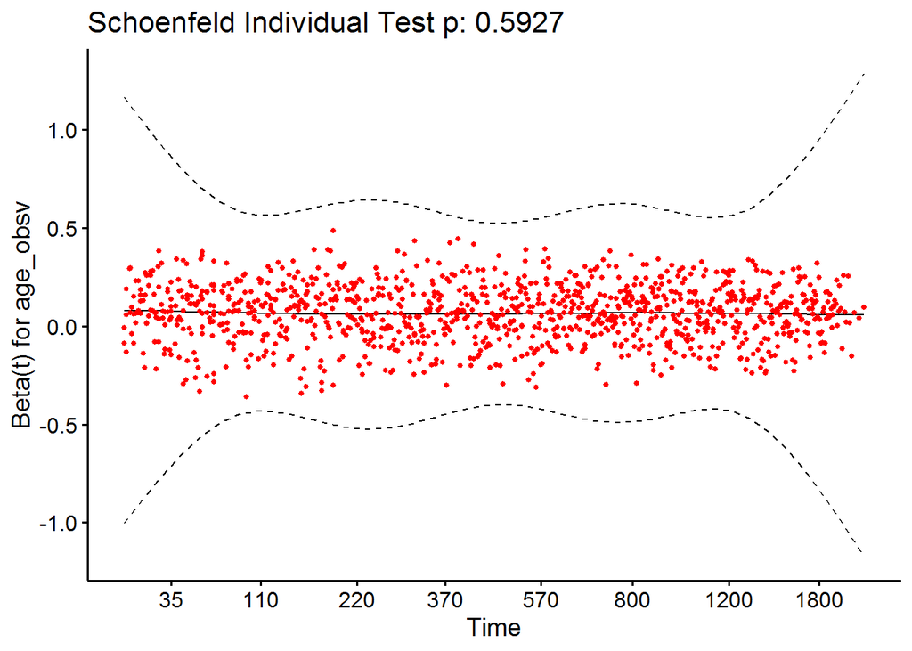

```r
ggcoxzph(resm16b)[2]
```

```
## $`2`
```

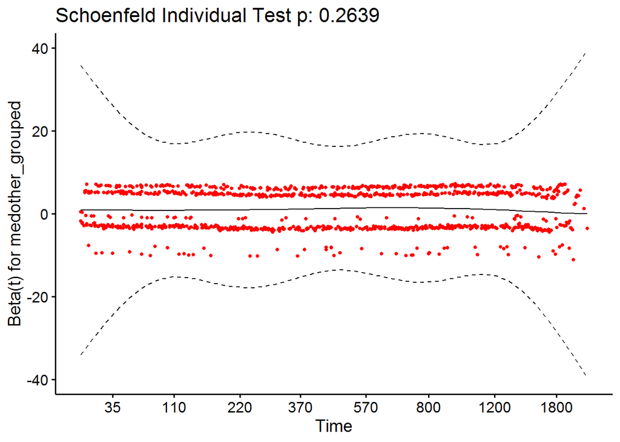

```r
anova(cox_m16b)
```

```
## Analysis of Deviance Table
##  Cox model: response is Surv(time1, time2, event_death)
## Terms added sequentially (first to last)
##
##                   loglik   Chisq Df Pr(>|Chi|)
## NULL             -6923.7
## age_obsv         -6810.2 226.991  1  < 2.2e-16 ***
## medother_grouped -6785.8  48.748  6  8.375e-09 ***
## ---
## Signif. codes:  0 '***' 0.001 '**' 0.01 '*' 0.05 '.' 0.1 ' ' 1
```

*Forest plot*

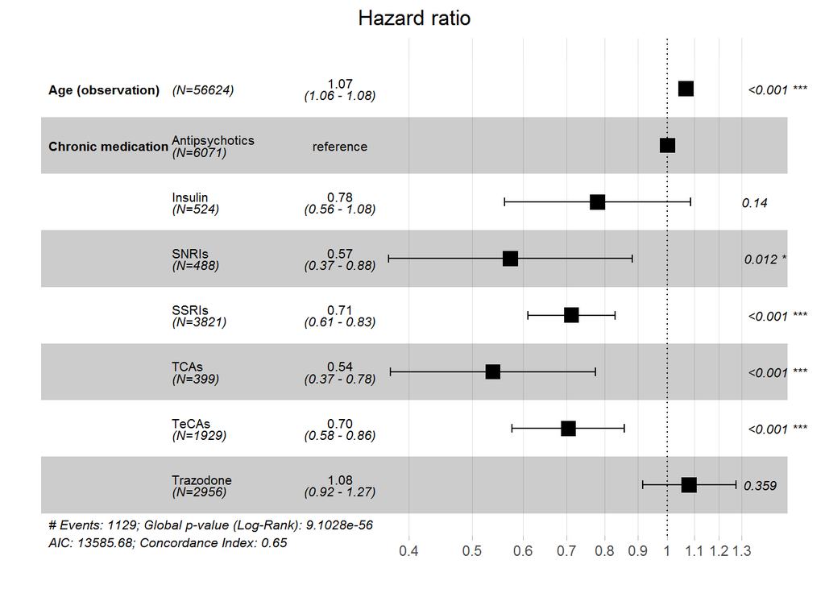

```r
forest_df16b <- all_df %>%
  transmute(time1,
            time2,
            event_death,
            `Age (observation)` = age_obsv,
            `Chronic medication` = medother_grouped)

new16b <- coxph(Surv(time1, time2, event_death) ~  `Age (observation)` + `Chronic medication`, data = forest_df16b)

ggforest(new16b,
         cpositions = c(0.01, 0.175, 0.4))
```

**Gender, age at observation, cognitive assessment score, and chronic medication**

```r
cox_m17 <- coxph(Surv(time1, time2, event_death) ~  Gender_Value + age_obsv + numerator + medother_grouped, data = all_df)

summary(cox_m17)
```

```
## Call:
## coxph(formula = Surv(time1, time2, event_death) ~ Gender_Value +
##     age_obsv + numerator + medother_grouped, data = all_df)
##
##   n= 4139, number of events= 263
##    (52485 observations deleted due to missingness)
##
##                                coef exp(coef)  se(coef)      z Pr(>|z|)
## Gender_ValueMale           0.129257  1.137983  0.131768  0.981   0.3266
## age_obsv                   0.090606  1.094837  0.009794  9.251  < 2e-16 ***
## numerator                 -0.067651  0.934586  0.009183 -7.367 1.74e-13 ***
## medother_groupedInsulin    0.171952  1.187621  0.285480  0.602   0.5470
## medother_groupedSNRIs      0.157439  1.170510  0.373056  0.422   0.6730
## medother_groupedSSRIs     -0.359926  0.697728  0.184930 -1.946   0.0516 .
## medother_groupedTCAs      -0.676225  0.508533  0.297078 -2.276   0.0228 *
## medother_groupedTeCAs     -0.464674  0.628340  0.233072 -1.994   0.0462 *
## medother_groupedTrazodone -0.051444  0.949857  0.222533 -0.231   0.8172
## ---
## Signif. codes:  0 '***' 0.001 '**' 0.01 '*' 0.05 '.' 0.1 ' ' 1
##
##                           exp(coef) exp(-coef) lower .95 upper .95
## Gender_ValueMale             1.1380     0.8787    0.8790    1.4733
## age_obsv                     1.0948     0.9134    1.0740    1.1161
## numerator                    0.9346     1.0700    0.9179    0.9516
## medother_groupedInsulin      1.1876     0.8420    0.6787    2.0782
## medother_groupedSNRIs        1.1705     0.8543    0.5634    2.4318
## medother_groupedSSRIs        0.6977     1.4332    0.4856    1.0025
## medother_groupedTCAs         0.5085     1.9664    0.2841    0.9103
## medother_groupedTeCAs        0.6283     1.5915    0.3979    0.9922
## medother_groupedTrazodone    0.9499     1.0528    0.6141    1.4692
##
## Concordance= 0.731  (se = 0.019 )
## Likelihood ratio test= 159.7  on 9 df,   p=<2e-16
## Wald test            = 153.2  on 9 df,   p=<2e-16
## Score (logrank) test = 157.4  on 9 df,   p=<2e-16
```

```r
cox.zph(cox_m17)
```

```
##                  chisq df    p
## Gender_Value     0.566  1 0.45
## age_obsv         0.681  1 0.41
## numerator        0.707  1 0.40
## medother_grouped 3.471  6 0.75
## GLOBAL           5.313  9 0.81
```

```r
resm17 <- cox.zph(cox_m17)

ggcoxzph(resm17)[1]
```

```
## $`1`
```

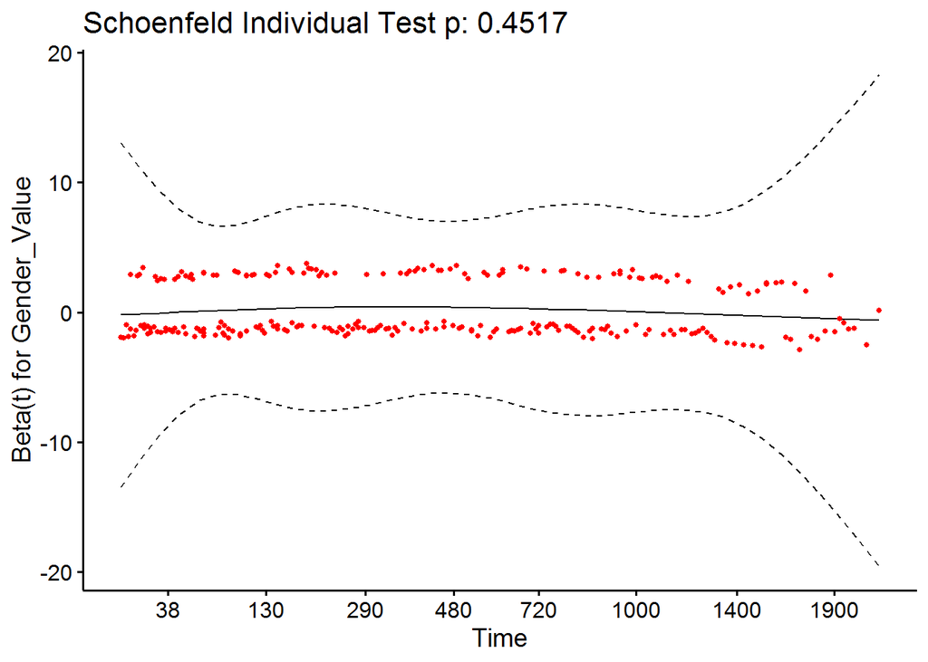

```r
ggcoxzph(resm17)[2]
```

```
## $`2`
```

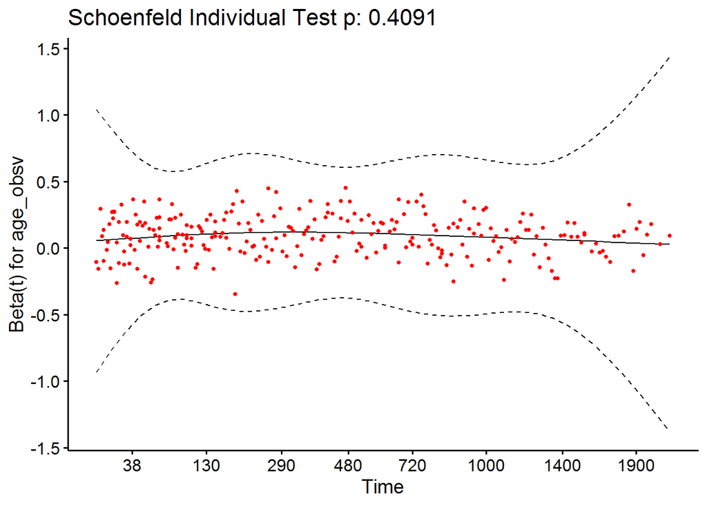

```r
ggcoxzph(resm17)[3]
```

```
## $`3`
```

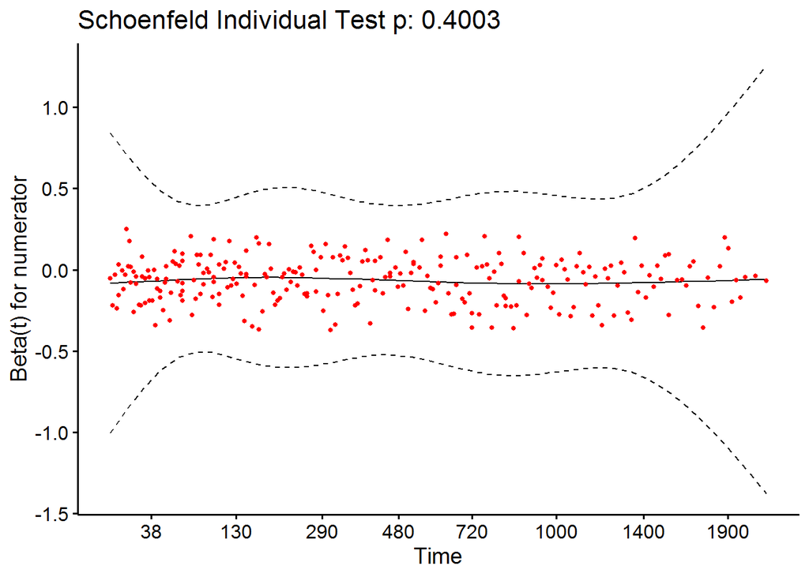

```r
ggcoxzph(resm17)[4]
```

```
## $`4`
```

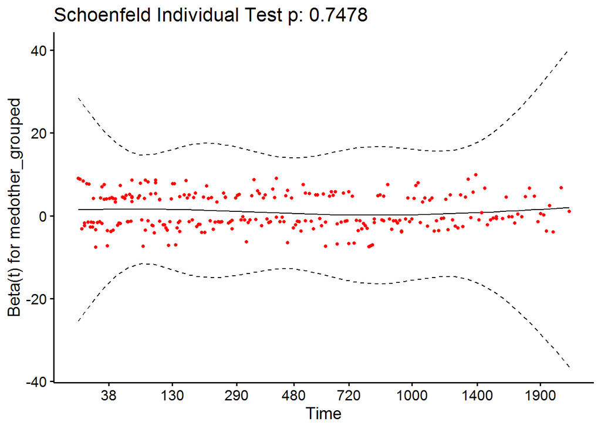

```r
anova(cox_m17)
```

```
## Analysis of Deviance Table
##  Cox model: response is Surv(time1, time2, event_death)
## Terms added sequentially (first to last)
##
##                   loglik   Chisq Df Pr(>|Chi|)
## NULL             -1315.0
## Gender_Value     -1315.0  0.0533  1    0.81745
## age_obsv         -1268.5 92.9549  1  < 2.2e-16 ***
## numerator        -1242.1 52.7597  1   3.77e-13 ***
## medother_grouped -1235.2 13.9199  6    0.03054 *
## ---
## Signif. codes:  0 '***' 0.001 '**' 0.01 '*' 0.05 '.' 0.1 ' ' 1
```

We removed gender:

**Age at observation, cognitive assessment score, and chronic medication**

```r
cox_m17a <- coxph(Surv(time1, time2, event_death) ~ age_obsv + numerator + medother_grouped, data = all_df)

summary(cox_m17a)
```

```
## Call:
## coxph(formula = Surv(time1, time2, event_death) ~ age_obsv +
##     numerator + medother_grouped, data = all_df)
##
##   n= 4139, number of events= 263
##    (52485 observations deleted due to missingness)
##
##                                coef exp(coef)  se(coef)      z Pr(>|z|)
## age_obsv                   0.089863  1.094024  0.009785  9.184  < 2e-16 ***
## numerator                 -0.067724  0.934518  0.009201 -7.361 1.83e-13 ***
## medother_groupedInsulin    0.189398  1.208522  0.284959  0.665   0.5063
## medother_groupedSNRIs      0.173696  1.189694  0.372717  0.466   0.6412
## medother_groupedSSRIs     -0.356059  0.700431  0.184823 -1.926   0.0540 .
## medother_groupedTCAs      -0.702123  0.495532  0.295839 -2.373   0.0176 *
## medother_groupedTeCAs     -0.460455  0.630997  0.233060 -1.976   0.0482 *
## medother_groupedTrazodone -0.044512  0.956464  0.222524 -0.200   0.8415
## ---
## Signif. codes:  0 '***' 0.001 '**' 0.01 '*' 0.05 '.' 0.1 ' ' 1
##
##                           exp(coef) exp(-coef) lower .95 upper .95
## age_obsv                     1.0940     0.9141    1.0732    1.1152
## numerator                    0.9345     1.0701    0.9178    0.9515
## medother_groupedInsulin      1.2085     0.8275    0.6913    2.1126
## medother_groupedSNRIs        1.1897     0.8406    0.5730    2.4700
## medother_groupedSSRIs        0.7004     1.4277    0.4876    1.0062
## medother_groupedTCAs         0.4955     2.0180    0.2775    0.8849
## medother_groupedTeCAs        0.6310     1.5848    0.3996    0.9963
## medother_groupedTrazodone    0.9565     1.0455    0.6184    1.4794
##
## Concordance= 0.731  (se = 0.019 )
## Likelihood ratio test= 158.7  on 8 df,   p=<2e-16
## Wald test            = 151.4  on 8 df,   p=<2e-16
## Score (logrank) test = 155.9  on 8 df,   p=<2e-16
```

```r
cox.zph(cox_m17a)
```

```
##                  chisq df    p
## age_obsv         0.652  1 0.42
## numerator        0.771  1 0.38
## medother_grouped 3.549  6 0.74
## GLOBAL           4.650  8 0.79
```

```r
resm17a <- cox.zph(cox_m17a)

ggcoxzph(resm17a)[1]
```

```
## $`1`
```

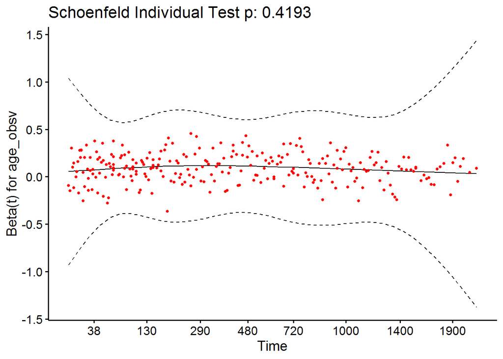

```r
ggcoxzph(resm17a)[2]
```

```
## $`2`
```

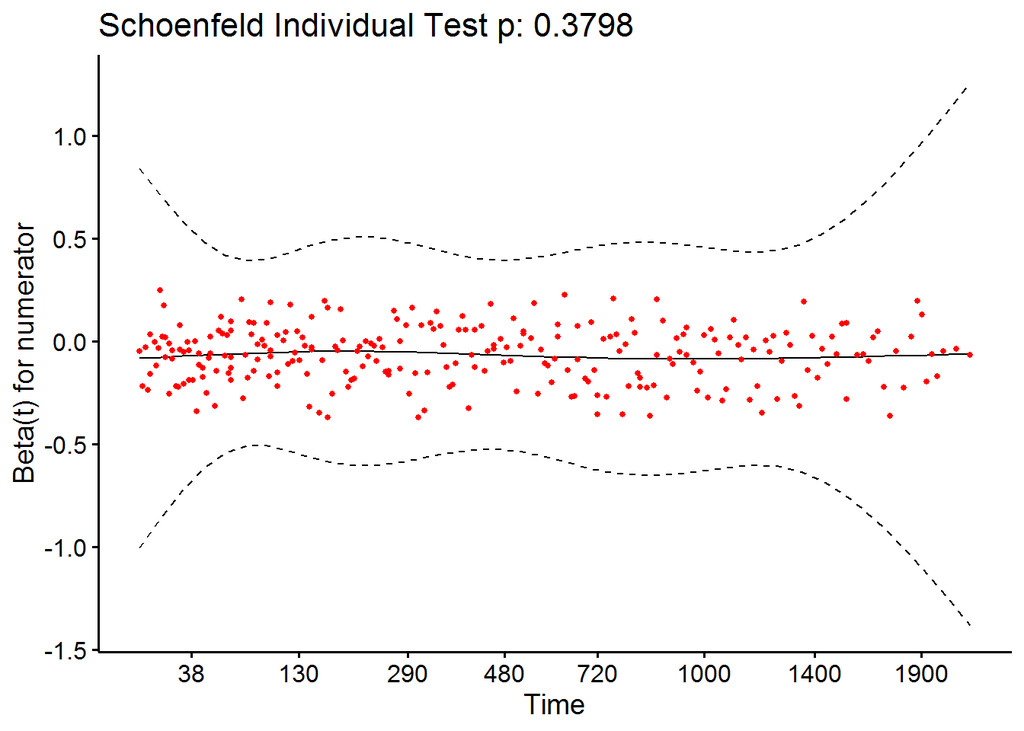

```r
ggcoxzph(resm17a)[3]
```

```
## $`3`
```

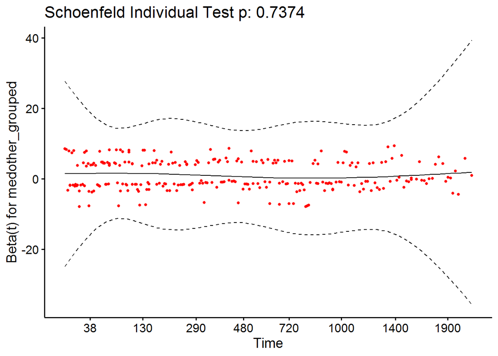

```r
anova(cox_m17a)
```

```
## Analysis of Deviance Table
##  Cox model: response is Surv(time1, time2, event_death)
## Terms added sequentially (first to last)
##
##                   loglik  Chisq Df Pr(>|Chi|)
## NULL             -1315.0
## age_obsv         -1269.5 91.016  1  < 2.2e-16 ***
## numerator        -1243.0 52.962  1  3.402e-13 ***
## medother_grouped -1235.7 14.759  6    0.02221 *
## ---
## Signif. codes:  0 '***' 0.001 '**' 0.01 '*' 0.05 '.' 0.1 ' ' 1
```

*Forest plot*

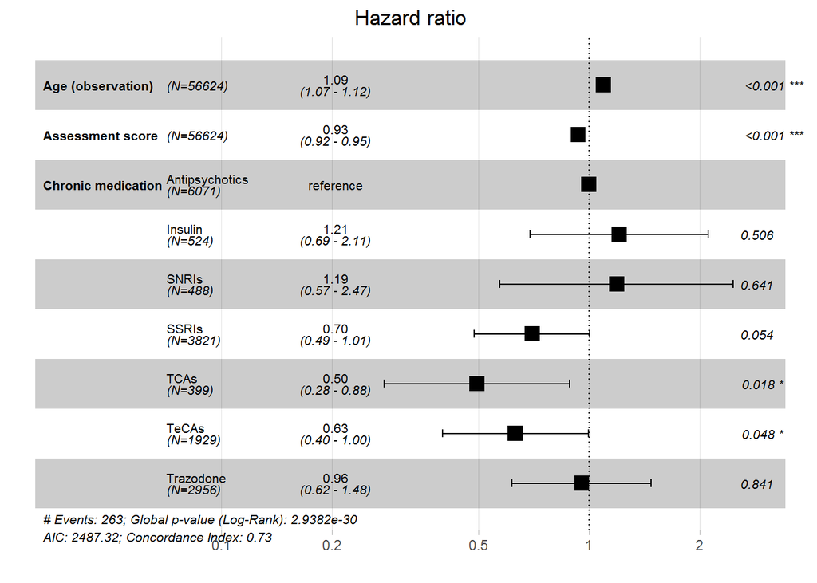

```r
forest_df17a <- all_df %>%
  transmute(time1,
            time2,
            event_death,
            `Age (observation)` = age_obsv,
            `Assessment score` = numerator,
            `Chronic medication` = medother_grouped)

new17a <- coxph(Surv(time1, time2, event_death) ~  `Age (observation)` + `Assessment score` + `Chronic medication`, data = forest_df17a)

ggforest(new17a,
         cpositions = c(0.01, 0.175, 0.4))
```

**Gender, age at observation, marital status, cognitive assessment score, and chronic medication**

```r
cox_m18 <- coxph(Surv(time1, time2, event_death) ~  Gender_Value + age_obsv + marital_status + numerator + medother_grouped, data = all_df)

summary(cox_m18)
```

```
## Call:
## coxph(formula = Surv(time1, time2, event_death) ~ Gender_Value +
##     age_obsv + marital_status + numerator + medother_grouped,
##     data = all_df)
##
##   n= 2506, number of events= 136
##    (54118 observations deleted due to missingness)
##
##                                      coef exp(coef) se(coef)      z Pr(>|z|)
## Gender_ValueMale                 -0.12549   0.88207  0.20240 -0.620    0.535
## age_obsv                          0.08280   1.08632  0.01574  5.261 1.43e-07
## marital_statusDivorced/Separated -0.39803   0.67164  0.60789 -0.655    0.513
## marital_statusSingle              0.02387   1.02416  0.44771  0.053    0.957
## marital_statusWidowed             0.16800   1.18293  0.21405  0.785    0.433
## numerator                        -0.07971   0.92339  0.01301 -6.124 9.10e-10
## medother_groupedInsulin           0.36154   1.43553  0.45034  0.803    0.422
## medother_groupedSNRIs             0.25535   1.29091  0.56771  0.450    0.653
## medother_groupedSSRIs            -0.22905   0.79529  0.26764 -0.856    0.392
## medother_groupedTCAs             -0.46232   0.62982  0.37833 -1.222    0.222
## medother_groupedTeCAs            -0.48994   0.61266  0.33312 -1.471    0.141
## medother_groupedTrazodone         0.04299   1.04392  0.32226  0.133    0.894
##
## Gender_ValueMale
## age_obsv                         ***
## marital_statusDivorced/Separated
## marital_statusSingle
## marital_statusWidowed
## numerator                        ***
## medother_groupedInsulin
## medother_groupedSNRIs
## medother_groupedSSRIs
## medother_groupedTCAs
## medother_groupedTeCAs
## medother_groupedTrazodone
## ---
## Signif. codes:  0 '***' 0.001 '**' 0.01 '*' 0.05 '.' 0.1 ' ' 1
##
##                                  exp(coef) exp(-coef) lower .95 upper .95
## Gender_ValueMale                    0.8821     1.1337    0.5932    1.3116
## age_obsv                            1.0863     0.9205    1.0533    1.1204
## marital_statusDivorced/Separated    0.6716     1.4889    0.2040    2.2109
## marital_statusSingle                1.0242     0.9764    0.4259    2.4630
## marital_statusWidowed               1.1829     0.8454    0.7776    1.7995
## numerator                           0.9234     1.0830    0.9001    0.9472
## medother_groupedInsulin             1.4355     0.6966    0.5939    3.4701
## medother_groupedSNRIs               1.2909     0.7746    0.4243    3.9276
## medother_groupedSSRIs               0.7953     1.2574    0.4707    1.3438
## medother_groupedTCAs                0.6298     1.5878    0.3000    1.3221
## medother_groupedTeCAs               0.6127     1.6322    0.3189    1.1770
## medother_groupedTrazodone           1.0439     0.9579    0.5551    1.9633
##
## Concordance= 0.751  (se = 0.024 )
## Likelihood ratio test= 90.72  on 12 df,   p=4e-14
## Wald test            = 85.5  on 12 df,   p=4e-13
## Score (logrank) test = 90.29  on 12 df,   p=4e-14
```

```r
cox.zph(cox_m18)
```

```
##                   chisq df     p
## Gender_Value      2.913  1 0.088
## age_obsv          2.664  1 0.103
## marital_status    0.780  3 0.854
## numerator         0.282  1 0.595
## medother_grouped  5.696  6 0.458
## GLOBAL           14.114 12 0.294
```

```r
resm18 <- cox.zph(cox_m18)

ggcoxzph(resm18)[1]
```

```
## $`1`
```

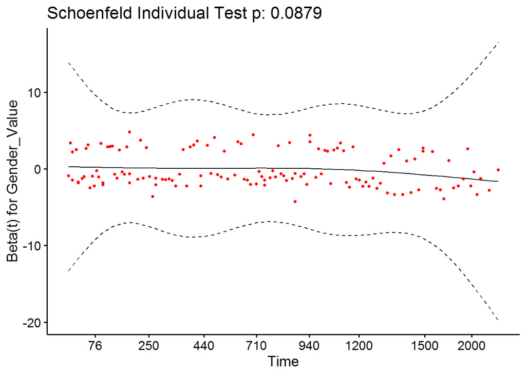

```r
ggcoxzph(resm18)[2]
```

```
## $`2`
```

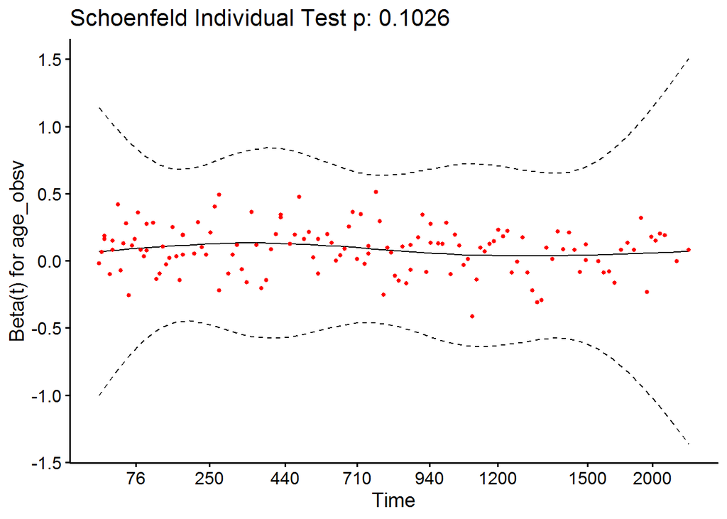

```r
ggcoxzph(resm18)[3]
```

```
## $`3`
```

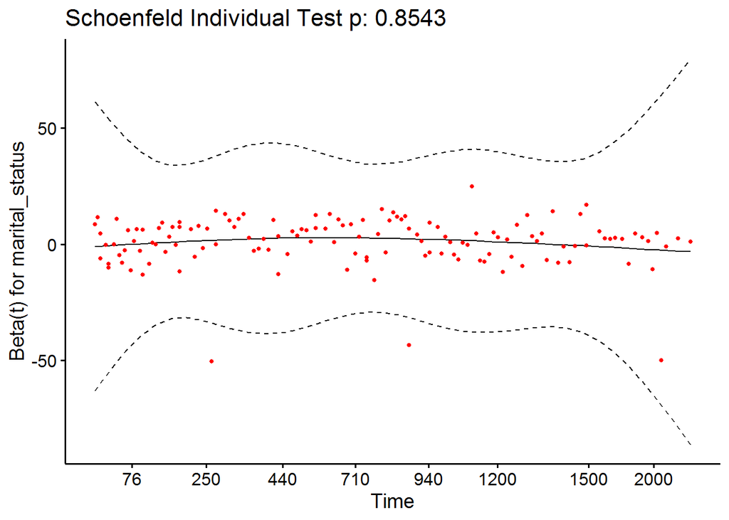

```r
ggcoxzph(resm18)[4]
```

```
## $`4`
```

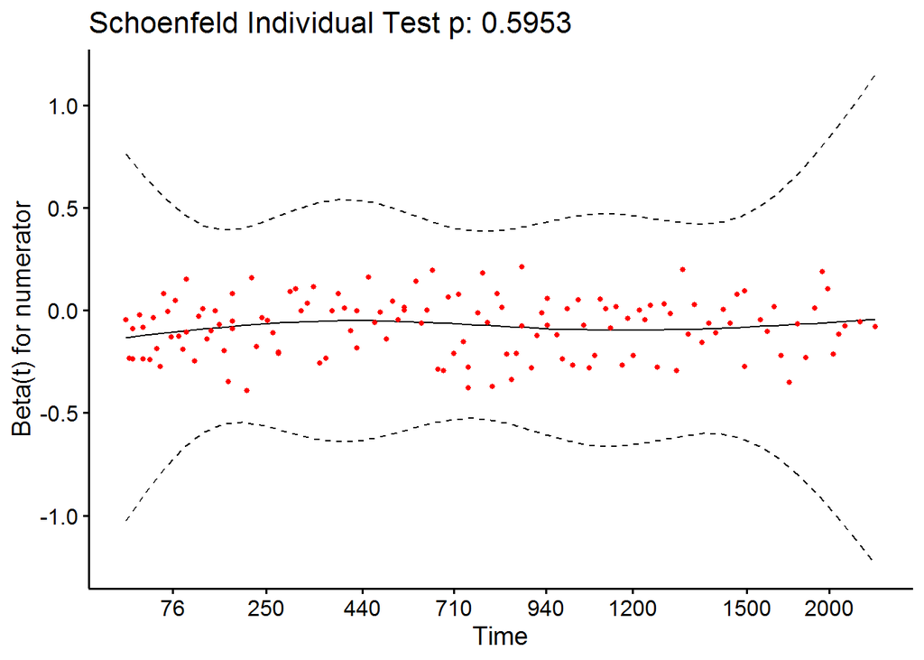

```r
ggcoxzph(resm18)[5]
```

```
## $`5`
```

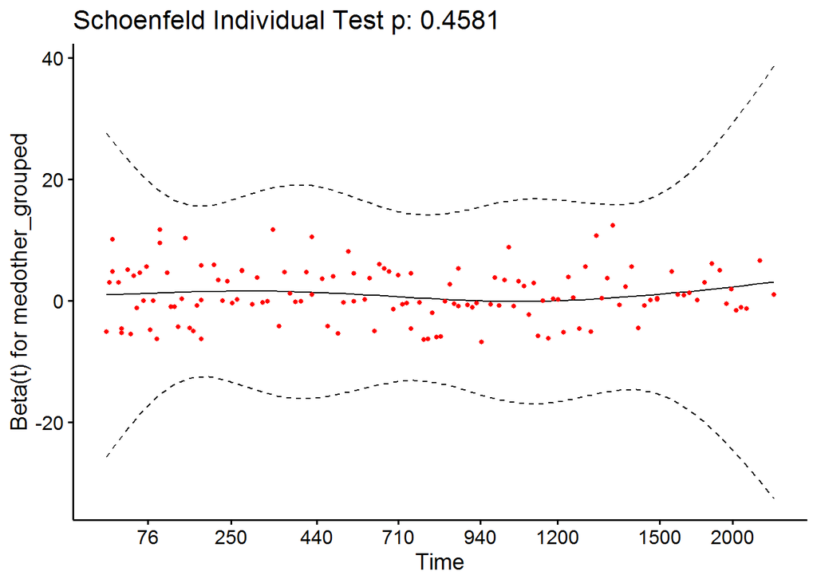

```r
anova(cox_m18)
```

```
## Analysis of Deviance Table
##  Cox model: response is Surv(time1, time2, event_death)
## Terms added sequentially (first to last)
##
##                   loglik   Chisq Df Pr(>|Chi|)
## NULL             -576.48
## Gender_Value     -575.65  1.6660  1     0.1968
## age_obsv         -553.88 43.5417  1  4.150e-11 ***
## marital_status   -553.02  1.7167  3     0.6332
## numerator        -534.43 37.1831  1  1.075e-09 ***
## medother_grouped -531.12  6.6127  6     0.3582
## ---
## Signif. codes:  0 '***' 0.001 '**' 0.01 '*' 0.05 '.' 0.1 ' ' 1
```

We removed gender:

**Age at observation, marital status, cognitive assessment score, and chronic medication**

```r
cox_m18a <- coxph(Surv(time1, time2, event_death) ~ age_obsv + marital_status + numerator + medother_grouped, data = all_df)

summary(cox_m18a)
```

```
## Call:
## coxph(formula = Surv(time1, time2, event_death) ~ age_obsv +
##     marital_status + numerator + medother_grouped, data = all_df)
##
##   n= 2506, number of events= 136
##    (54118 observations deleted due to missingness)
##
##                                      coef exp(coef) se(coef)      z Pr(>|z|)
## age_obsv                          0.08345   1.08703  0.01574  5.301 1.15e-07
## marital_statusDivorced/Separated -0.37258   0.68895  0.60671 -0.614    0.539
## marital_statusSingle              0.03978   1.04059  0.44619  0.089    0.929
## marital_statusWidowed             0.20540   1.22801  0.20547  1.000    0.317
## numerator                        -0.07936   0.92371  0.01301 -6.099 1.07e-09
## medother_groupedInsulin           0.35852   1.43120  0.44994  0.797    0.426
## medother_groupedSNRIs             0.22553   1.25299  0.56510  0.399    0.690
## medother_groupedSSRIs            -0.22610   0.79764  0.26774 -0.844    0.398
## medother_groupedTCAs             -0.42950   0.65084  0.37478 -1.146    0.252
## medother_groupedTeCAs            -0.48876   0.61339  0.33303 -1.468    0.142
## medother_groupedTrazodone         0.03745   1.03816  0.32226  0.116    0.907
##
## age_obsv                         ***
## marital_statusDivorced/Separated
## marital_statusSingle
## marital_statusWidowed
## numerator                        ***
## medother_groupedInsulin
## medother_groupedSNRIs
## medother_groupedSSRIs
## medother_groupedTCAs
## medother_groupedTeCAs
## medother_groupedTrazodone
## ---
## Signif. codes:  0 '***' 0.001 '**' 0.01 '*' 0.05 '.' 0.1 ' ' 1
##
##                                  exp(coef) exp(-coef) lower .95 upper .95
## age_obsv                            1.0870     0.9199    1.0540    1.1211
## marital_statusDivorced/Separated    0.6890     1.4515    0.2098    2.2627
## marital_statusSingle                1.0406     0.9610    0.4340    2.4950
## marital_statusWidowed               1.2280     0.8143    0.8209    1.8370
## numerator                           0.9237     1.0826    0.9004    0.9476
## medother_groupedInsulin             1.4312     0.6987    0.5925    3.4570
## medother_groupedSNRIs               1.2530     0.7981    0.4139    3.7928
## medother_groupedSSRIs               0.7976     1.2537    0.4720    1.3481
## medother_groupedTCAs                0.6508     1.5365    0.3122    1.3567
## medother_groupedTeCAs               0.6134     1.6303    0.3193    1.1782
## medother_groupedTrazodone           1.0382     0.9632    0.5520    1.9524
##
## Concordance= 0.751  (se = 0.024 )
## Likelihood ratio test= 90.33  on 11 df,   p=1e-14
## Wald test            = 84.87  on 11 df,   p=2e-13
## Score (logrank) test = 89.73  on 11 df,   p=2e-14
```

```r
cox.zph(cox_m18a)
```

```
##                  chisq df     p
## age_obsv         2.845  1 0.092
## marital_status   0.867  3 0.833
## numerator        0.349  1 0.555
## medother_grouped 5.590  6 0.471
## GLOBAL           9.019 11 0.620
```

```r
resm18a <- cox.zph(cox_m18a)

ggcoxzph(resm18a)[1]
```

```
## $`1`
```

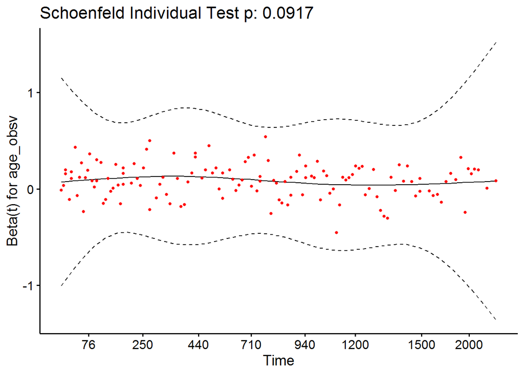